# Portfolios_10

Qilin Zhang

2023-04-20

## Cleaning

```r
##scale construction
HEXACO <- dict %>%
  filter (scale == "HEXACO_C") %>%
  pull(variable)
M6 <- dict %>%
  filter (M6 != "NA") %>%
  pull(variable)

data <- data%>%
  select(!c(DGS_31,DGS_53)) %>%
  select(c(M6,HEXACO,Age,Gender,Race,Degree,Income,Religion))
```

```r
metadata(data)$name <- "A short name for the data"
metadata(data)$description <- "Longer description of the dataset"
metadata(data)$temporalCoverage <- "Timespan of data collection"

codebook(data, metadata_json = F, metadata_table = F) #generate codebook, excluding some messy meta-data
```

```
## No missing values.
```

### Metadata

#### Description

**Metadata for search engines**

| x |
| --- |
| DGS_12 |
| DGS_15 |
| DGS_17 |
| DGS_18 |
| DGS_19 |
| DGS_30 |
| DGS_32 |
| DGS_33 |
| DGS_34 |
| DGS_36 |
| DGS_49 |
| DGS_57 |
| DGS_58 |
| DGS_60 |
| DGS_61 |
| DGS_63 |
| DGS_75 |
| DGS_5 |
| DGS_10 |
| DGS_26 |
| DGS_41 |
| DGS_54 |
| DGS_69 |
| DGS_72 |
| DGS_9 |
| DGS_27 |
| DGS_29 |
| DGS_46 |
| DGS_52 |
| DGS_28 |
| DGS_35 |
| DGS_48 |
| DGS_68 |
| DGS_21 |
| DGS_44 |
| DGS_65 |
| DGS_6 |
| DGS_38 |
| DGS_39 |
| DGS_70 |
| DGS_71 |
| DGS_56 |
| HEXACO_C_1 |
| HEXACO_C_2 |
| HEXACO_C_3 |
| HEXACO_C_4 |
| HEXACO_C_5 |
| HEXACO_C_6 |
| HEXACO_C_7 |
| HEXACO_C_8 |
| HEXACO_C_9 |
| HEXACO_C_10 |
| Age |
| Gender |
| Race |
| Degree |
| Income |
| Religion |

### DGS_12

I will listen closely to the people that I help

#### Distribution

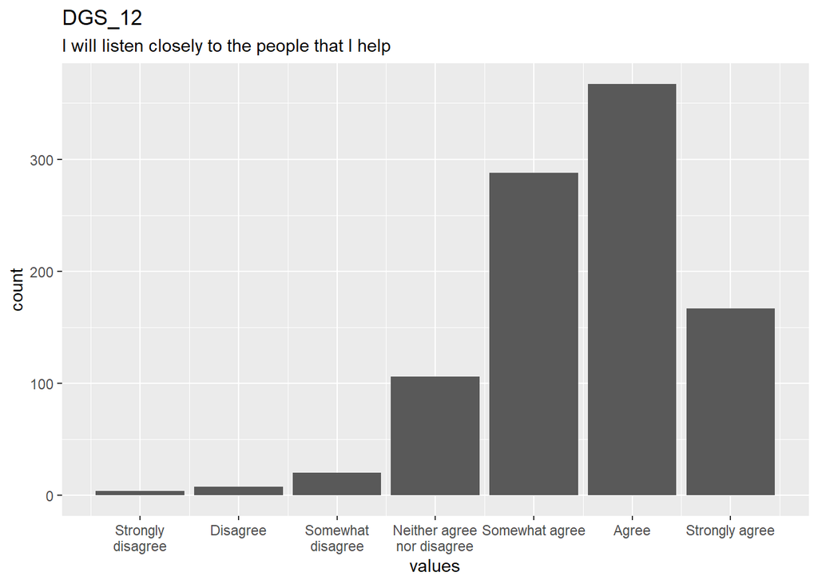

Distribution of values for DGS_12

0 missing values.

#### Summary statistics

| name | label | data_type | n_missing | complete_rate | min | median | max | mean | sd | n_value_labels | hist |
| --- | --- | --- | --- | --- | --- | --- | --- | --- | --- | --- | --- |
| DGS_12 | I will listen closely to the people that I help | haven_labelled | 0 | 1 | 1 | 6 | 7 | 5.536458 | 1.061569 | 7 | ▁▁▁▂▁▆▇▃ |

#### Value labels

Response choices

| name | value |
| --- | --- |
| Strongly disagree | 1 |
| Disagree | 2 |
| Somewhat disagree | 3 |
| Neither agree nor disagree | 4 |
| Somewhat agree | 5 |
| Agree | 6 |
| Strongly agree | 7 |

### DGS_15

I am happy to help despite not everyone doing it

#### Distribution

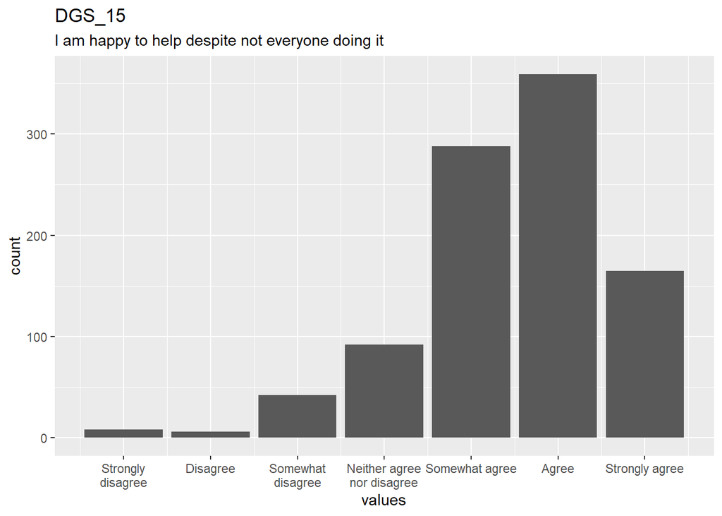

Distribution of values for DGS_15

0 missing values.

#### Summary statistics

| name | label | data_type | n_missing | complete_rate | min | median | max | mean | sd | n_value_labels | hist |
| --- | --- | --- | --- | --- | --- | --- | --- | --- | --- | --- | --- |
| DGS_15 | I am happy to help despite not everyone doing it | haven_labelled | 0 | 1 | 1 | 6 | 7 | 5.482292 | 1.136052 | 7 | ▁▁▁▂▁▆▇▃ |

#### Value labels

Response choices

| name | value |
| --- | --- |
| Strongly disagree | 1 |
| Disagree | 2 |
| Somewhat disagree | 3 |
| Neither agree nor disagree | 4 |
| Somewhat agree | 5 |
| Agree | 6 |
| Strongly agree | 7 |

### DGS_17

When I help others, I am motivated by the urge to do good

#### Distribution

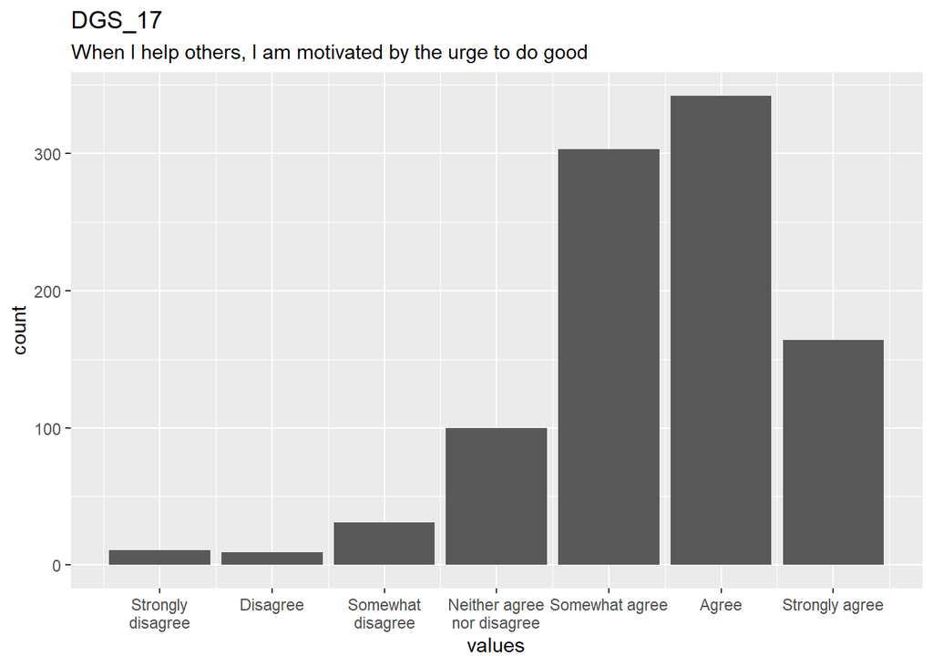

Distribution of values for DGS_17

0 missing values.

#### Summary statistics

| name | label | data_type | n_missing | complete_rate | min | median | max | mean | sd | n_value_labels | hist |
| --- | --- | --- | --- | --- | --- | --- | --- | --- | --- | --- | --- |
| DGS_17 | When I help others, I am motivated by the urge to do good | haven_labelled | 0 | 1 | 1 | 6 | 7 | 5.455208 | 1.155336 | 7 | ▁▁▁▂▁▇▇▃ |

#### Value labels

Response choices

| name | value |
| --- | --- |
| Strongly disagree | 1 |
| Disagree | 2 |
| Somewhat disagree | 3 |
| Neither agree nor disagree | 4 |
| Somewhat agree | 5 |
| Agree | 6 |
| Strongly agree | 7 |

### DGS_18

I help everyone as I can, not just my close friends

#### Distribution

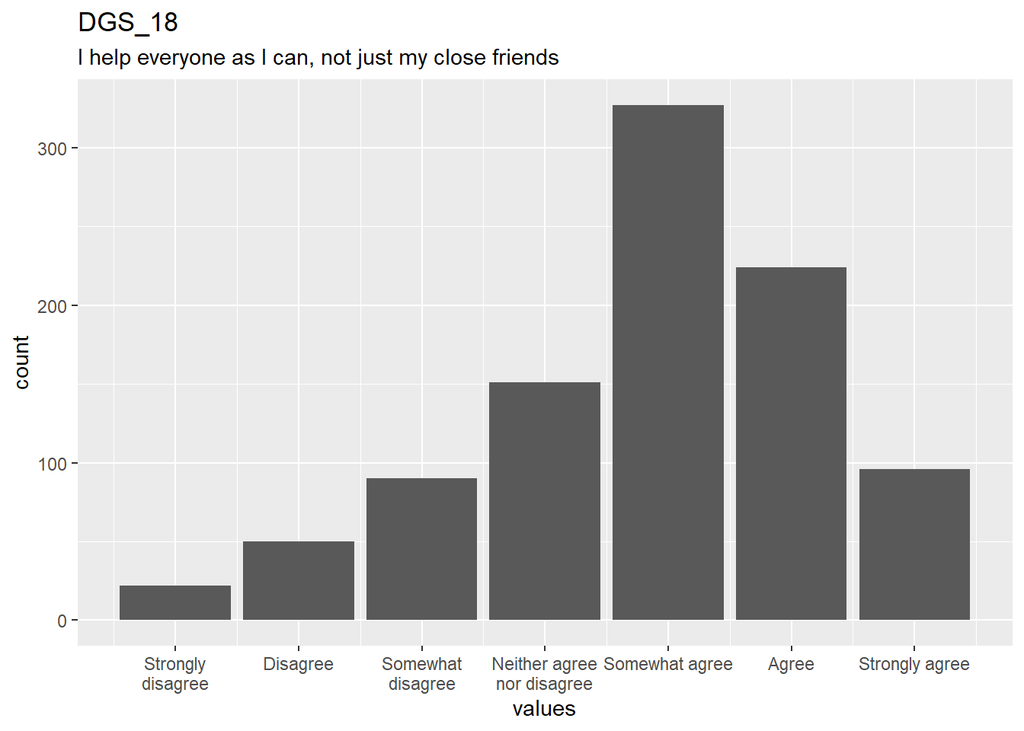

Distribution of values for DGS_18

0 missing values.

#### Summary statistics

| name | label | data_type | n_missing | complete_rate | min | median | max | mean | sd | n_value_labels | hist |
| --- | --- | --- | --- | --- | --- | --- | --- | --- | --- | --- | --- |
| DGS_18 | I help everyone as I can, not just my close friends | haven_labelled | 0 | 1 | 1 | 5 | 7 | 4.840625 | 1.406308 | 7 | ▁▁▂▃▁▇▆▂ |

#### Value labels

Response choices

| name | value |
| --- | --- |
| Strongly disagree | 1 |
| Disagree | 2 |
| Somewhat disagree | 3 |
| Neither agree nor disagree | 4 |
| Somewhat agree | 5 |
| Agree | 6 |
| Strongly agree | 7 |

### DGS_19

I help in ways that optimize happiness for everyone

#### Distribution

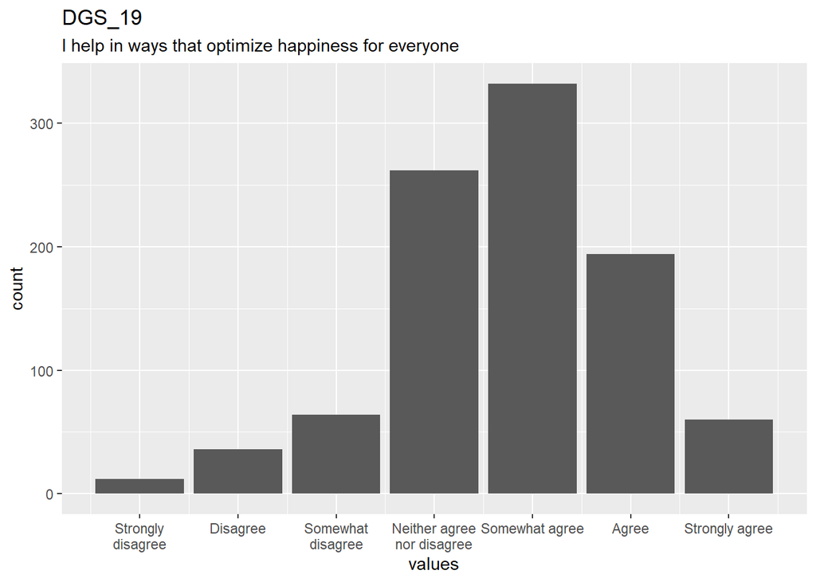

Distribution of values for DGS_19

0 missing values.

#### Summary statistics

| name | label | data_type | n_missing | complete_rate | min | median | max | mean | sd | n_value_labels | hist |
| --- | --- | --- | --- | --- | --- | --- | --- | --- | --- | --- | --- |
| DGS_19 | I help in ways that optimize happiness for everyone | haven_labelled | 0 | 1 | 1 | 5 | 7 | 4.758333 | 1.213383 | 7 | ▁▁▂▆▁▇▅▂ |

#### Value labels

Response choices

| name | value |
| --- | --- |
| Strongly disagree | 1 |
| Disagree | 2 |
| Somewhat disagree | 3 |
| Neither agree nor disagree | 4 |
| Somewhat agree | 5 |
| Agree | 6 |
| Strongly agree | 7 |

### DGS_30

I will do my best to help despite not knowing the people I help

#### Distribution

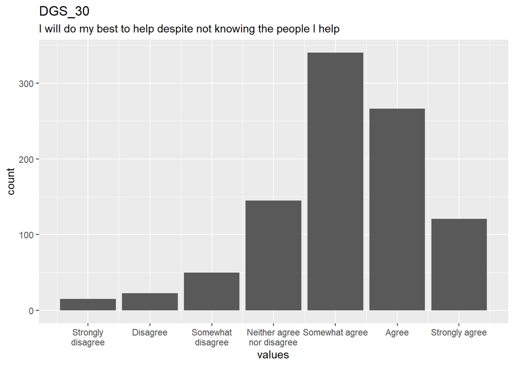

Distribution of values for DGS_30

0 missing values.

#### Summary statistics

| name | label | data_type | n_missing | complete_rate | min | median | max | mean | sd | n_value_labels | hist |
| --- | --- | --- | --- | --- | --- | --- | --- | --- | --- | --- | --- |
| DGS_30 | I will do my best to help despite not knowing the people I help | haven_labelled | 0 | 1 | 1 | 5 | 7 | 5.139583 | 1.260326 | 7 | ▁▁▁▃▁▇▆▃ |

#### Value labels

Response choices

| name | value |
| --- | --- |
| Strongly disagree | 1 |
| Disagree | 2 |
| Somewhat disagree | 3 |
| Neither agree nor disagree | 4 |
| Somewhat agree | 5 |
| Agree | 6 |
| Strongly agree | 7 |

### DGS_32

I try, more than anything else, to do good

#### Distribution

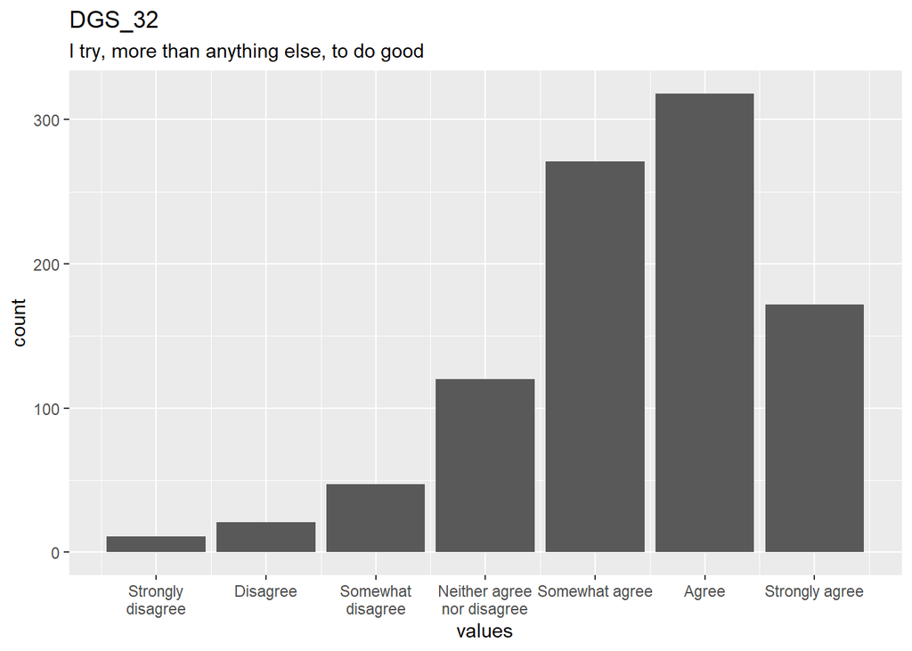

Distribution of values for DGS_32

0 missing values.

#### Summary statistics

| name | label | data_type | n_missing | complete_rate | min | median | max | mean | sd | n_value_labels | hist |
| --- | --- | --- | --- | --- | --- | --- | --- | --- | --- | --- | --- |
| DGS_32 | I try, more than anything else, to do good | haven_labelled | 0 | 1 | 1 | 6 | 7 | 5.355208 | 1.27455 | 7 | ▁▁▁▃▁▇▇▅ |

#### Value labels

Response choices

| name | value |
| --- | --- |
| Strongly disagree | 1 |
| Disagree | 2 |
| Somewhat disagree | 3 |
| Neither agree nor disagree | 4 |
| Somewhat agree | 5 |
| Agree | 6 |
| Strongly agree | 7 |

### DGS_33

I help because I think it is the best thing to do

#### Distribution

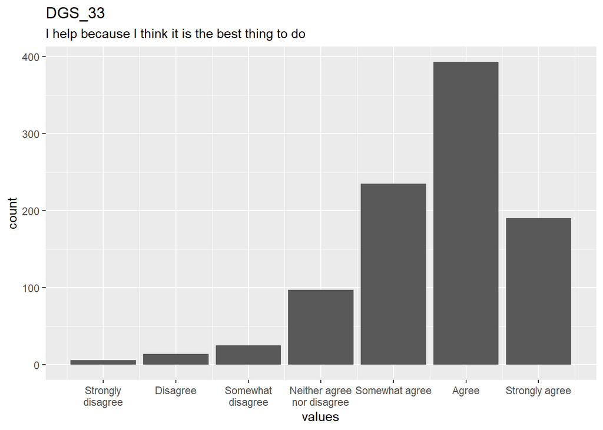

Distribution of values for DGS_33

0 missing values.

#### Summary statistics

| name | label | data_type | n_missing | complete_rate | min | median | max | mean | sd | n_value_labels | hist |
| --- | --- | --- | --- | --- | --- | --- | --- | --- | --- | --- | --- |
| DGS_33 | I help because I think it is the best thing to do | haven_labelled | 0 | 1 | 1 | 6 | 7 | 5.583333 | 1.13955 | 7 | ▁▁▁▂▁▅▇▃ |

#### Value labels

Response choices

| name | value |
| --- | --- |
| Strongly disagree | 1 |
| Disagree | 2 |
| Somewhat disagree | 3 |
| Neither agree nor disagree | 4 |
| Somewhat agree | 5 |
| Agree | 6 |
| Strongly agree | 7 |

### DGS_34

We need to develop an understanding of others to provide better help

#### Distribution

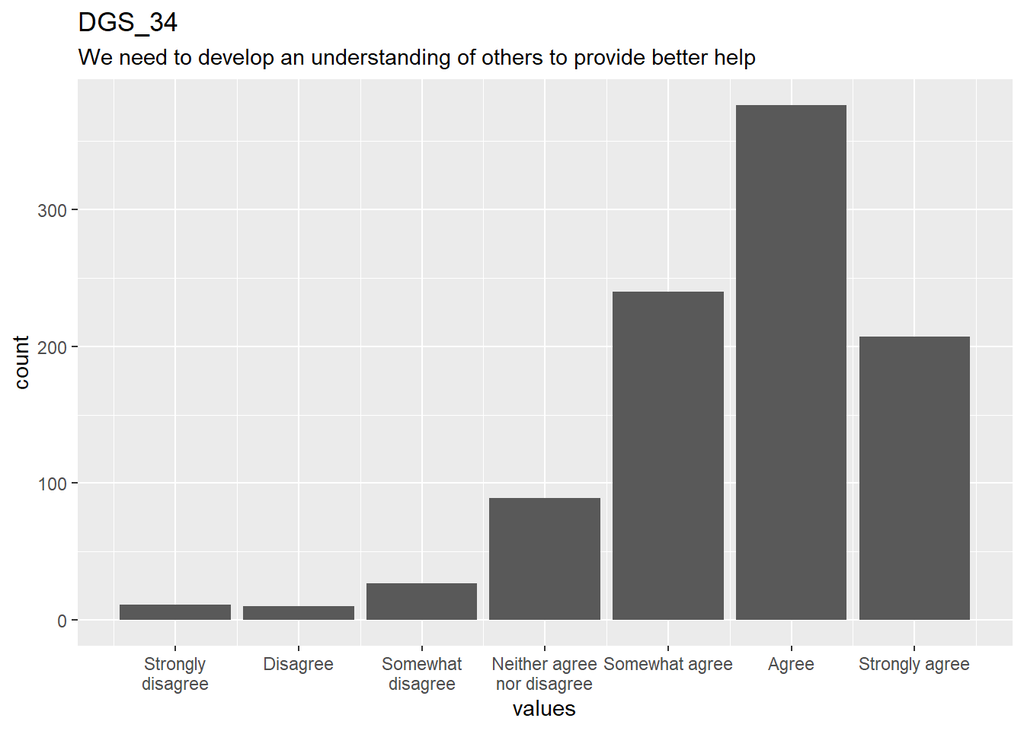

Distribution of values for DGS_34

0 missing values.

#### Summary statistics

| name | label | data_type | n_missing | complete_rate | min | median | max | mean | sd | n_value_labels | hist |
| --- | --- | --- | --- | --- | --- | --- | --- | --- | --- | --- | --- |
| DGS_34 | We need to develop an understanding of others to provide better help | haven_labelled | 0 | 1 | 1 | 6 | 7 | 5.596875 | 1.175431 | 7 | ▁▁▁▂▁▅▇▅ |

#### Value labels

Response choices

| name | value |
| --- | --- |
| Strongly disagree | 1 |
| Disagree | 2 |
| Somewhat disagree | 3 |
| Neither agree nor disagree | 4 |
| Somewhat agree | 5 |
| Agree | 6 |
| Strongly agree | 7 |

### DGS_36

Fighting for the greater good is rooted in my values

#### Distribution

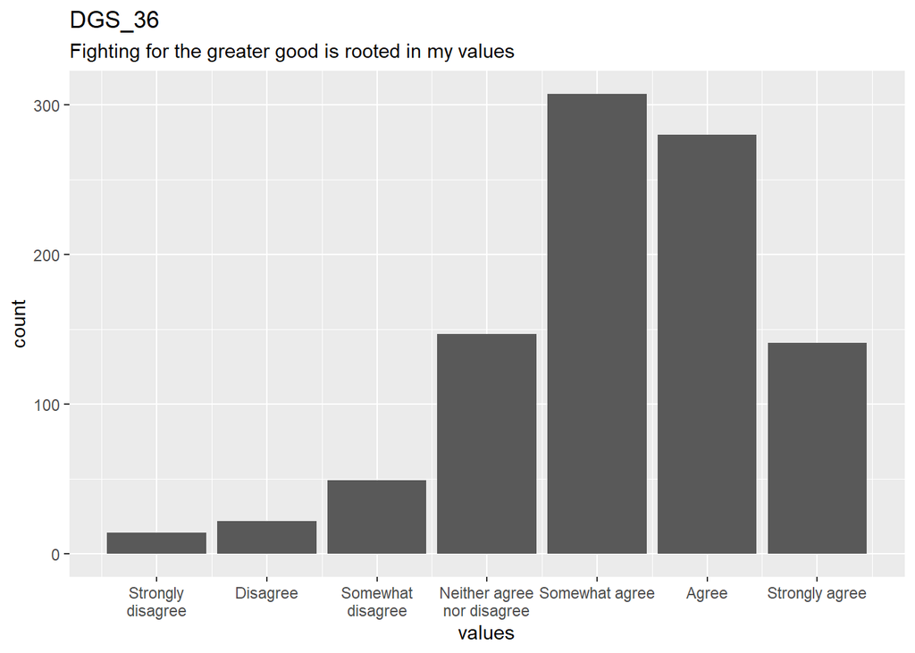

Distribution of values for DGS_36

0 missing values.

#### Summary statistics

| name | label | data_type | n_missing | complete_rate | min | median | max | mean | sd | n_value_labels | hist |
| --- | --- | --- | --- | --- | --- | --- | --- | --- | --- | --- | --- |
| DGS_36 | Fighting for the greater good is rooted in my values | haven_labelled | 0 | 1 | 1 | 5 | 7 | 5.203125 | 1.279252 | 7 | ▁▁▁▃▁▇▇▃ |

#### Value labels

Response choices

| name | value |
| --- | --- |
| Strongly disagree | 1 |
| Disagree | 2 |
| Somewhat disagree | 3 |
| Neither agree nor disagree | 4 |
| Somewhat agree | 5 |
| Agree | 6 |
| Strongly agree | 7 |

### DGS_49

I am always seeking more ways to help

#### Distribution

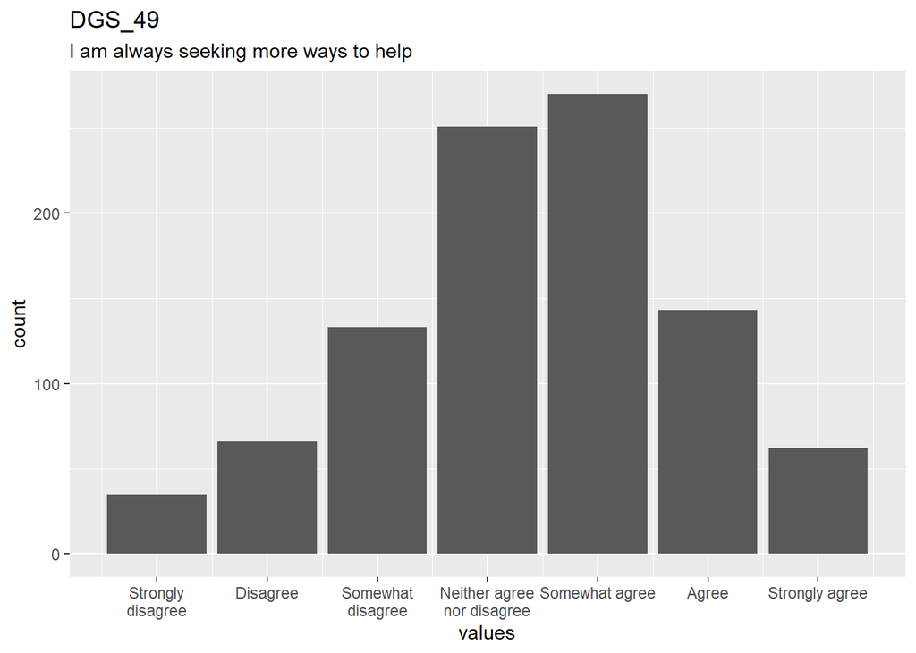

Distribution of values for DGS_49

0 missing values.

#### Summary statistics

| name | label | data_type | n_missing | complete_rate | min | median | max | mean | sd | n_value_labels | hist |
| --- | --- | --- | --- | --- | --- | --- | --- | --- | --- | --- | --- |
| DGS_49 | I am always seeking more ways to help | haven_labelled | 0 | 1 | 1 | 4 | 7 | 4.3875 | 1.432474 | 7 | ▁▂▃▇▁▇▅▂ |

#### Value labels

Response choices

| name | value |
| --- | --- |
| Strongly disagree | 1 |
| Disagree | 2 |
| Somewhat disagree | 3 |
| Neither agree nor disagree | 4 |
| Somewhat agree | 5 |
| Agree | 6 |
| Strongly agree | 7 |

### DGS_57

It is important to help others, regardless of the rewards

#### Distribution

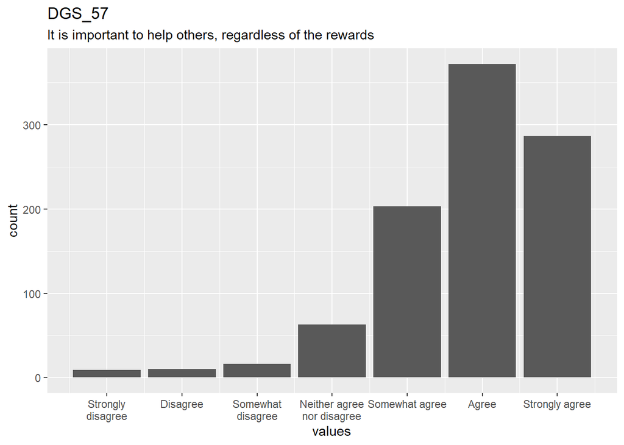

Distribution of values for DGS_57

0 missing values.

#### Summary statistics

| name | label | data_type | n_missing | complete_rate | min | median | max | mean | sd | n_value_labels | hist |
| --- | --- | --- | --- | --- | --- | --- | --- | --- | --- | --- | --- |
| DGS_57 | It is important to help others, regardless of the rewards | haven_labelled | 0 | 1 | 1 | 6 | 7 | 5.817708 | 1.136694 | 7 | ▁▁▁▂▁▅▇▆ |

#### Value labels

Response choices

| name | value |
| --- | --- |
| Strongly disagree | 1 |
| Disagree | 2 |
| Somewhat disagree | 3 |
| Neither agree nor disagree | 4 |
| Somewhat agree | 5 |
| Agree | 6 |
| Strongly agree | 7 |

### DGS_58

If we each help others as we can, the world would be a better place

#### Distribution

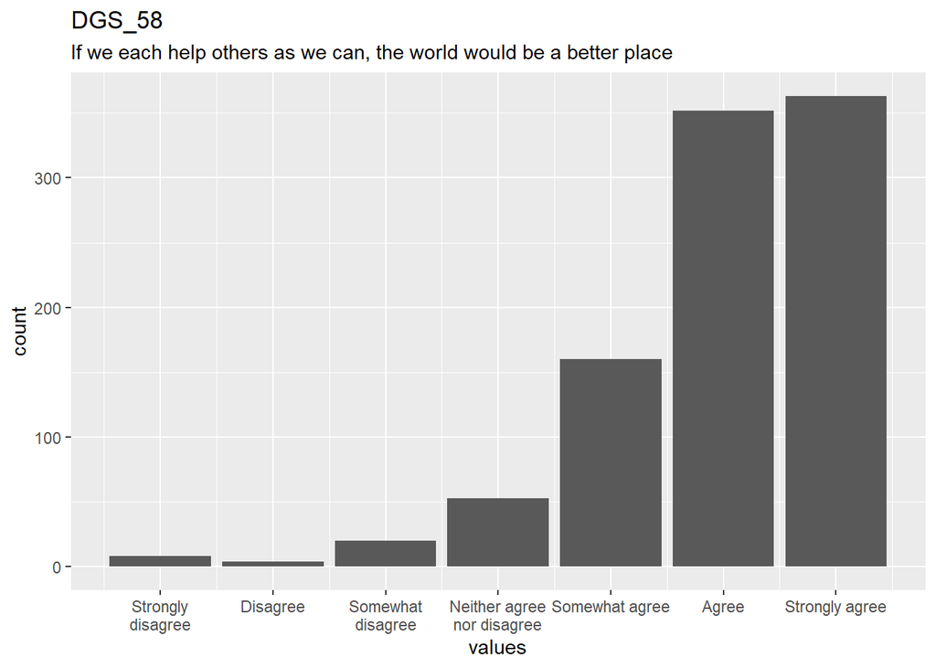

Distribution of values for DGS_58

0 missing values.

#### Summary statistics

| name | label | data_type | n_missing | complete_rate | min | median | max | mean | sd | n_value_labels | hist |
| --- | --- | --- | --- | --- | --- | --- | --- | --- | --- | --- | --- |
| DGS_58 | If we each help others as we can, the world would be a better place | haven_labelled | 0 | 1 | 1 | 6 | 7 | 5.980208 | 1.108609 | 7 | ▁▁▁▁▁▃▇▇ |

#### Value labels

Response choices

| name | value |
| --- | --- |
| Strongly disagree | 1 |
| Disagree | 2 |
| Somewhat disagree | 3 |
| Neither agree nor disagree | 4 |
| Somewhat agree | 5 |
| Agree | 6 |
| Strongly agree | 7 |

### DGS_60

I seek to make the world a better place than it is right now

#### Distribution

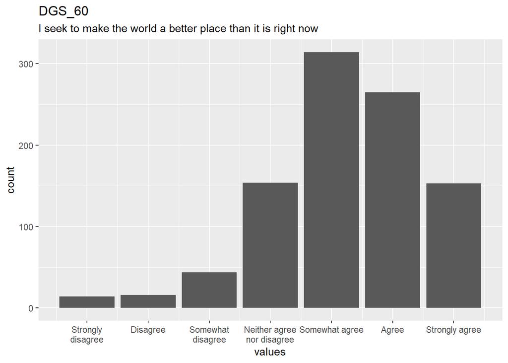

Distribution of values for DGS_60

0 missing values.

#### Summary statistics

| name | label | data_type | n_missing | complete_rate | min | median | max | mean | sd | n_value_labels | hist |
| --- | --- | --- | --- | --- | --- | --- | --- | --- | --- | --- | --- |
| DGS_60 | I seek to make the world a better place than it is right now | haven_labelled | 0 | 1 | 1 | 5 | 7 | 5.234375 | 1.259899 | 7 | ▁▁▁▃▁▇▇▃ |

#### Value labels

Response choices

| name | value |
| --- | --- |
| Strongly disagree | 1 |
| Disagree | 2 |
| Somewhat disagree | 3 |
| Neither agree nor disagree | 4 |
| Somewhat agree | 5 |
| Agree | 6 |
| Strongly agree | 7 |

### DGS_61

I will keep contributing to the greater good despite only being able to make small contributions

#### Distribution

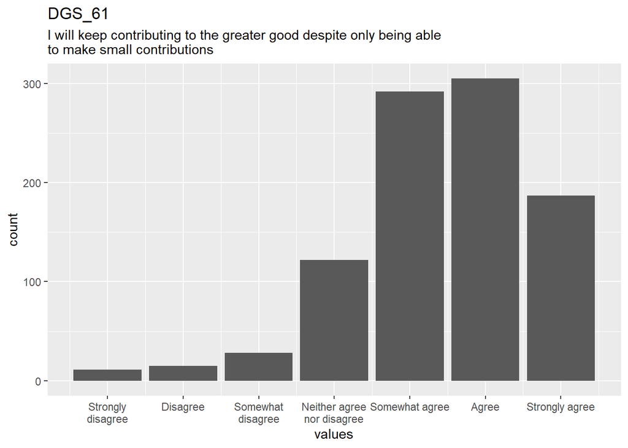

Distribution of values for DGS_61

0 missing values.

#### Summary statistics

| name | label | data_type | n_missing | complete_rate | min | median | max | mean | sd | n_value_labels | hist |
| --- | --- | --- | --- | --- | --- | --- | --- | --- | --- | --- | --- |
| DGS_61 | I will keep contributing to the greater good despite only being able to make small contributions | haven_labelled | 0 | 1 | 1 | 6 | 7 | 5.429167 | 1.217351 | 7 | ▁▁▁▃▁▇▇▅ |

#### Value labels

Response choices

| name | value |
| --- | --- |
| Strongly disagree | 1 |
| Disagree | 2 |
| Somewhat disagree | 3 |
| Neither agree nor disagree | 4 |
| Somewhat agree | 5 |
| Agree | 6 |
| Strongly agree | 7 |

### DGS_63

I believe small efforts combine to make substantial changes

#### Distribution

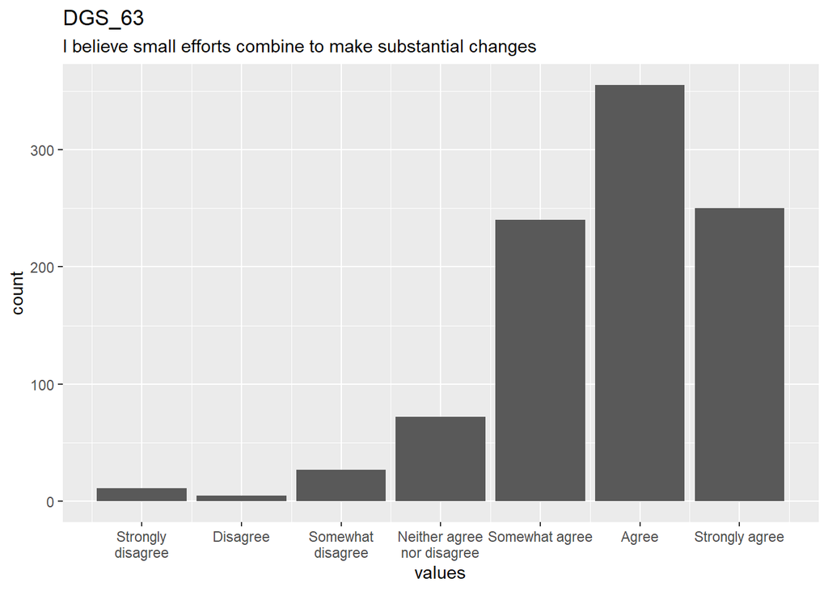

Distribution of values for DGS_63

0 missing values.

#### Summary statistics

| name | label | data_type | n_missing | complete_rate | min | median | max | mean | sd | n_value_labels | hist |
| --- | --- | --- | --- | --- | --- | --- | --- | --- | --- | --- | --- |
| DGS_63 | I believe small efforts combine to make substantial changes | haven_labelled | 0 | 1 | 1 | 6 | 7 | 5.697917 | 1.159085 | 7 | ▁▁▁▂▁▆▇▆ |

#### Value labels

Response choices

| name | value |
| --- | --- |
| Strongly disagree | 1 |
| Disagree | 2 |
| Somewhat disagree | 3 |
| Neither agree nor disagree | 4 |
| Somewhat agree | 5 |
| Agree | 6 |
| Strongly agree | 7 |

### DGS_75

I try to figure out the best way to help others instead of choosing the most simple ways

#### Distribution

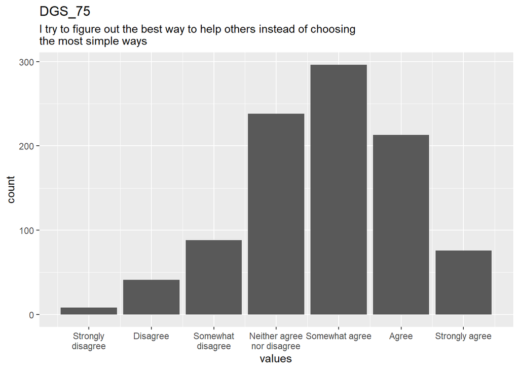

Distribution of values for DGS_75

0 missing values.

#### Summary statistics

| name | label | data_type | n_missing | complete_rate | min | median | max | mean | sd | n_value_labels | hist |
| --- | --- | --- | --- | --- | --- | --- | --- | --- | --- | --- | --- |
| DGS_75 | I try to figure out the best way to help others instead of choosing the most simple ways | haven_labelled | 0 | 1 | 1 | 5 | 7 | 4.7875 | 1.275685 | 7 | ▁▁▂▆▁▇▆▂ |

#### Value labels

Response choices

| name | value |
| --- | --- |
| Strongly disagree | 1 |
| Disagree | 2 |
| Somewhat disagree | 3 |
| Neither agree nor disagree | 4 |
| Somewhat agree | 5 |
| Agree | 6 |
| Strongly agree | 7 |

### DGS_5

I help only when I am asked to do so

#### Distribution

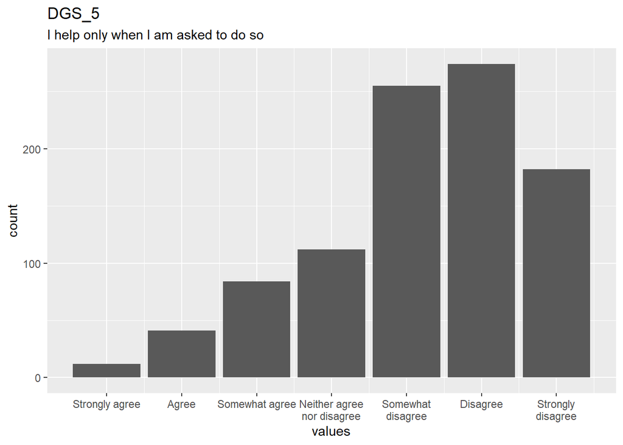

Distribution of values for DGS_5

0 missing values.

#### Summary statistics

| name | label | data_type | n_missing | complete_rate | min | median | max | mean | sd | n_value_labels | hist |
| --- | --- | --- | --- | --- | --- | --- | --- | --- | --- | --- | --- |
| DGS_5 | I help only when I am asked to do so | haven_labelled | 0 | 1 | 1 | 5 | 7 | 5.194792 | 1.434919 | 7 | ▁▁▂▃▁▇▇▅ |

#### Value labels

Response choices

| name | value |
| --- | --- |
| Strongly disagree | 7 |
| Disagree | 6 |
| Somewhat disagree | 5 |
| Neither agree nor disagree | 4 |
| Somewhat agree | 3 |
| Agree | 2 |
| Strongly agree | 1 |

### DGS_10

I am willing to help only when I can get something in return

#### Distribution

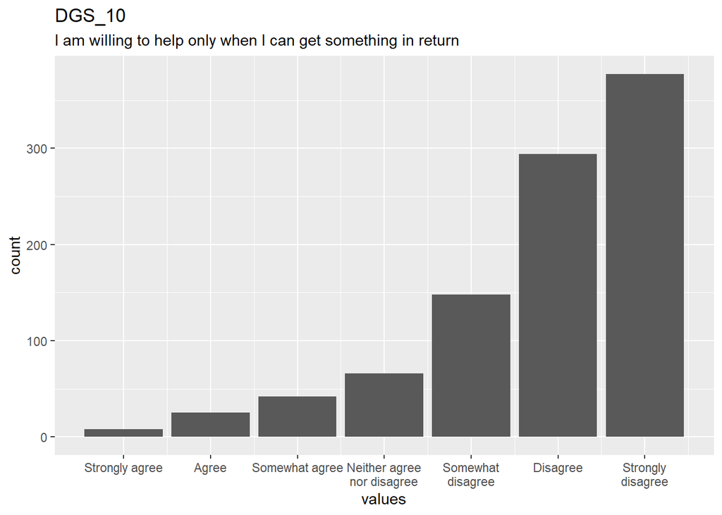

Distribution of values for DGS_10

0 missing values.

#### Summary statistics

| name | label | data_type | n_missing | complete_rate | min | median | max | mean | sd | n_value_labels | hist |
| --- | --- | --- | --- | --- | --- | --- | --- | --- | --- | --- | --- |
| DGS_10 | I am willing to help only when I can get something in return | haven_labelled | 0 | 1 | 1 | 6 | 7 | 5.823958 | 1.345928 | 7 | ▁▁▁▂▁▃▆▇ |

#### Value labels

Response choices

| name | value |
| --- | --- |
| Strongly disagree | 7 |
| Disagree | 6 |
| Somewhat disagree | 5 |
| Neither agree nor disagree | 4 |
| Somewhat agree | 3 |
| Agree | 2 |
| Strongly agree | 1 |

### DGS_26

I only help when other people help

#### Distribution

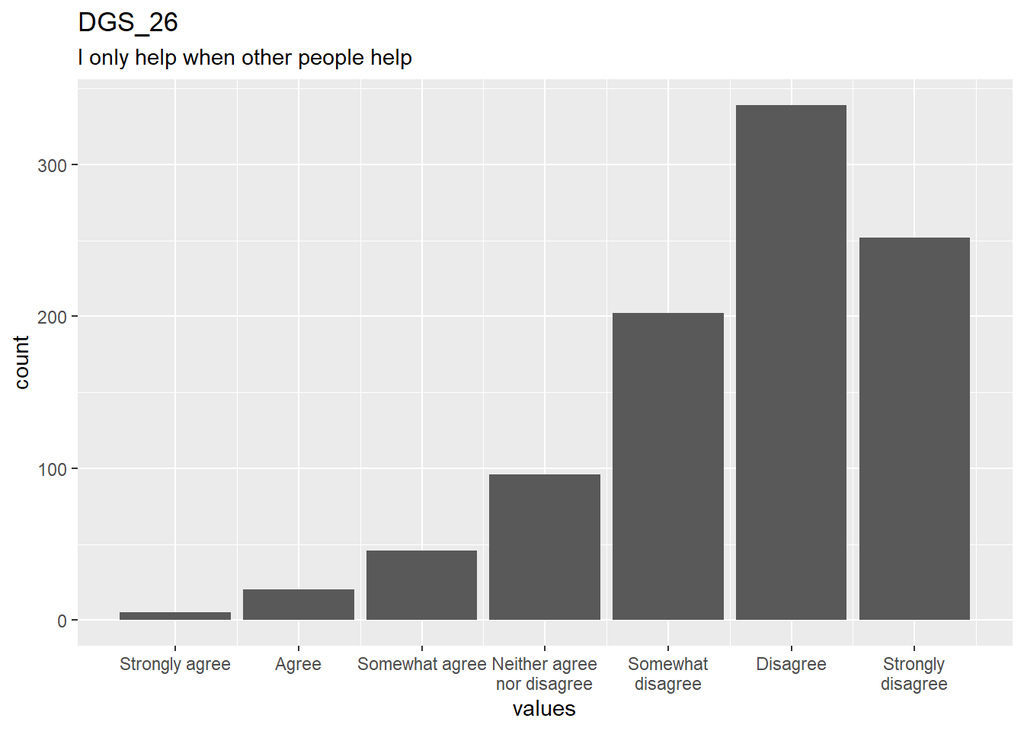

Distribution of values for DGS_26

0 missing values.

#### Summary statistics

| name | label | data_type | n_missing | complete_rate | min | median | max | mean | sd | n_value_labels | hist |
| --- | --- | --- | --- | --- | --- | --- | --- | --- | --- | --- | --- |
| DGS_26 | I only help when other people help | haven_labelled | 0 | 1 | 1 | 6 | 7 | 5.598958 | 1.268286 | 7 | ▁▁▁▂▁▅▇▆ |

#### Value labels

Response choices

| name | value |
| --- | --- |
| Strongly disagree | 7 |
| Disagree | 6 |
| Somewhat disagree | 5 |
| Neither agree nor disagree | 4 |
| Somewhat agree | 3 |
| Agree | 2 |
| Strongly agree | 1 |

### DGS_41

When I help someone, I expect them to return the favor

#### Distribution

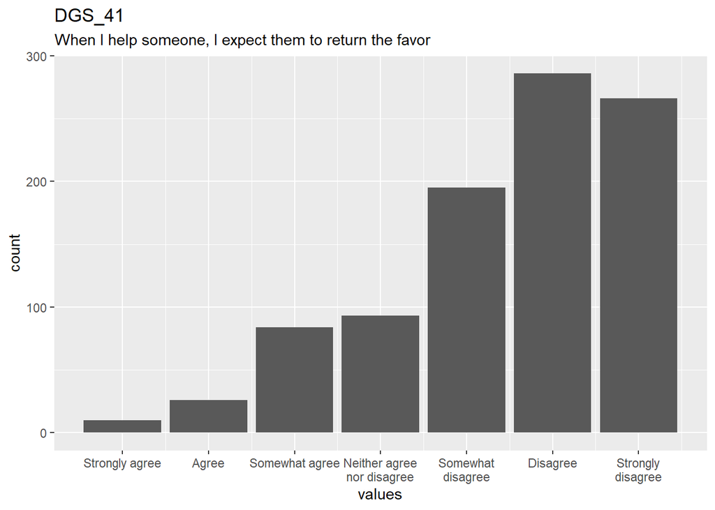

Distribution of values for DGS_41

0 missing values.

#### Summary statistics

| name | label | data_type | n_missing | complete_rate | min | median | max | mean | sd | n_value_labels | hist |
| --- | --- | --- | --- | --- | --- | --- | --- | --- | --- | --- | --- |
| DGS_41 | When I help someone, I expect them to return the favor | haven_labelled | 0 | 1 | 1 | 6 | 7 | 5.457292 | 1.434074 | 7 | ▁▁▂▂▁▆▇▇ |

#### Value labels

Response choices

| name | value |
| --- | --- |
| Strongly disagree | 7 |
| Disagree | 6 |
| Somewhat disagree | 5 |
| Neither agree nor disagree | 4 |
| Somewhat agree | 3 |
| Agree | 2 |
| Strongly agree | 1 |

### DGS_54

The world is fine where it is right now

#### Distribution

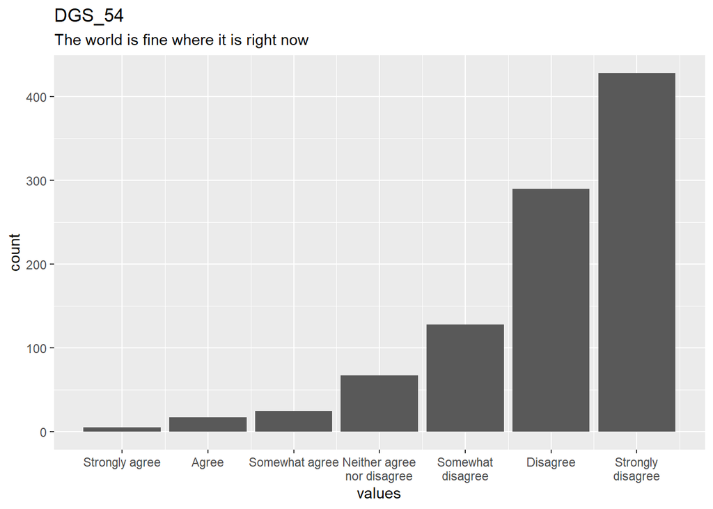

Distribution of values for DGS_54

0 missing values.

#### Summary statistics

| name | label | data_type | n_missing | complete_rate | min | median | max | mean | sd | n_value_labels | hist |
| --- | --- | --- | --- | --- | --- | --- | --- | --- | --- | --- | --- |
| DGS_54 | The world is fine where it is right now | haven_labelled | 0 | 1 | 1 | 6 | 7 | 5.997917 | 1.227932 | 7 | ▁▁▁▁▁▂▆▇ |

#### Value labels

Response choices

| name | value |
| --- | --- |
| Strongly disagree | 7 |
| Disagree | 6 |
| Somewhat disagree | 5 |
| Neither agree nor disagree | 4 |
| Somewhat agree | 3 |
| Agree | 2 |
| Strongly agree | 1 |

### DGS_69

There is no point in helping when others are not doing the same thing

#### Distribution

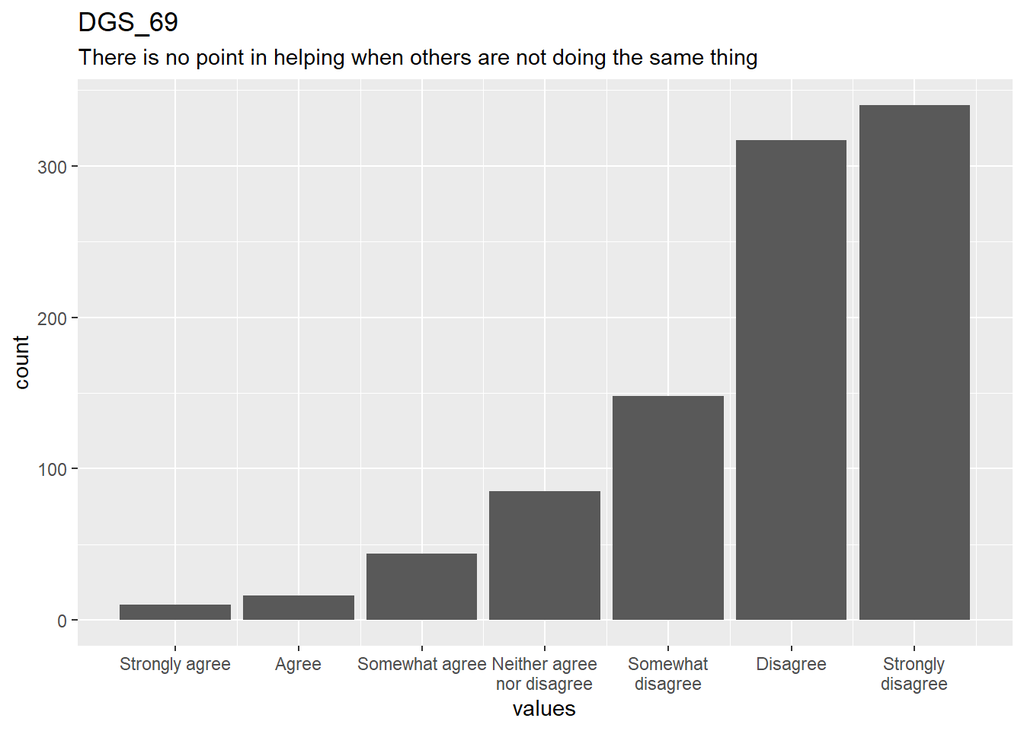

Distribution of values for DGS_69

0 missing values.

#### Summary statistics

| name | label | data_type | n_missing | complete_rate | min | median | max | mean | sd | n_value_labels | hist |
| --- | --- | --- | --- | --- | --- | --- | --- | --- | --- | --- | --- |
| DGS_69 | There is no point in helping when others are not doing the same thing | haven_labelled | 0 | 1 | 1 | 6 | 7 | 5.766667 | 1.322672 | 7 | ▁▁▁▂▁▃▇▇ |

#### Value labels

Response choices

| name | value |
| --- | --- |
| Strongly disagree | 7 |
| Disagree | 6 |
| Somewhat disagree | 5 |
| Neither agree nor disagree | 4 |
| Somewhat agree | 3 |
| Agree | 2 |
| Strongly agree | 1 |

### DGS_72

Helping acts should build on the potential benefits that I can gain

#### Distribution

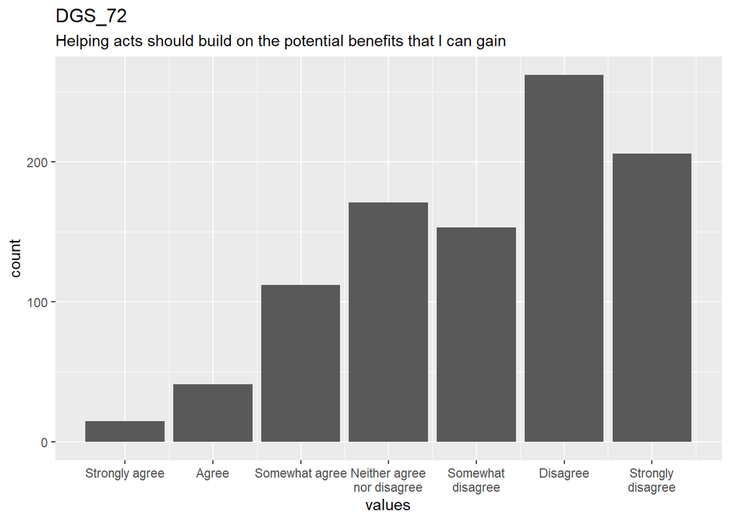

Distribution of values for DGS_72

0 missing values.

#### Summary statistics

| name | label | data_type | n_missing | complete_rate | min | median | max | mean | sd | n_value_labels | hist |
| --- | --- | --- | --- | --- | --- | --- | --- | --- | --- | --- | --- |
| DGS_72 | Helping acts should build on the potential benefits that I can gain | haven_labelled | 0 | 1 | 1 | 5 | 7 | 5.1 | 1.550135 | 7 | ▁▁▃▅▁▅▇▆ |

#### Value labels

Response choices

| name | value |
| --- | --- |
| Strongly disagree | 7 |
| Disagree | 6 |
| Somewhat disagree | 5 |
| Neither agree nor disagree | 4 |
| Somewhat agree | 3 |
| Agree | 2 |
| Strongly agree | 1 |

### DGS_9

Thinking about other people’s experiences does not affect me emotionally

#### Distribution

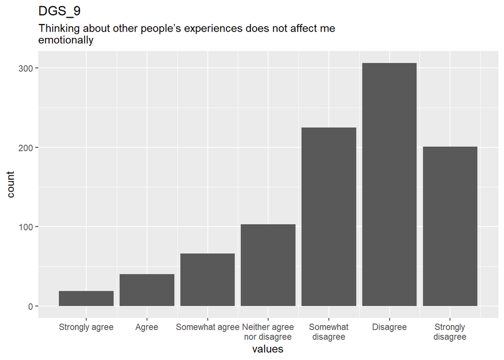

Distribution of values for DGS_9

0 missing values.

#### Summary statistics

| name | label | data_type | n_missing | complete_rate | min | median | max | mean | sd | n_value_labels | hist |
| --- | --- | --- | --- | --- | --- | --- | --- | --- | --- | --- | --- |
| DGS_9 | Thinking about other people’s experiences does not affect me emotionally | haven_labelled | 0 | 1 | 1 | 6 | 7 | 5.288542 | 1.466012 | 7 | ▁▁▂▃▁▆▇▅ |

#### Value labels

Response choices

| name | value |
| --- | --- |
| Strongly disagree | 7 |
| Disagree | 6 |
| Somewhat disagree | 5 |
| Neither agree nor disagree | 4 |
| Somewhat agree | 3 |
| Agree | 2 |
| Strongly agree | 1 |

### DGS_27

Even the most generic/basic description of others’ unfortunate experiences evokes my empathy

#### Distribution

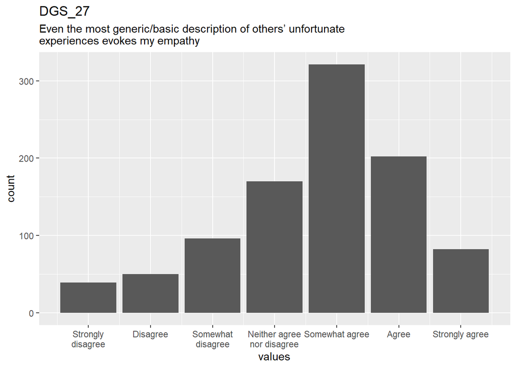

Distribution of values for DGS_27

0 missing values.

#### Summary statistics

| name | label | data_type | n_missing | complete_rate | min | median | max | mean | sd | n_value_labels | hist |
| --- | --- | --- | --- | --- | --- | --- | --- | --- | --- | --- | --- |
| DGS_27 | Even the most generic/basic description of others’ unfortunate experiences evokes my empathy | haven_labelled | 0 | 1 | 1 | 5 | 7 | 4.685417 | 1.466695 | 7 | ▁▁▂▅▁▇▅▂ |

#### Value labels

Response choices

| name | value |
| --- | --- |
| Strongly disagree | 1 |
| Disagree | 2 |
| Somewhat disagree | 3 |
| Neither agree nor disagree | 4 |
| Somewhat agree | 5 |
| Agree | 6 |
| Strongly agree | 7 |

### DGS_29

Thinking about the horrors people have endured in the past almost brings me to tears

#### Distribution

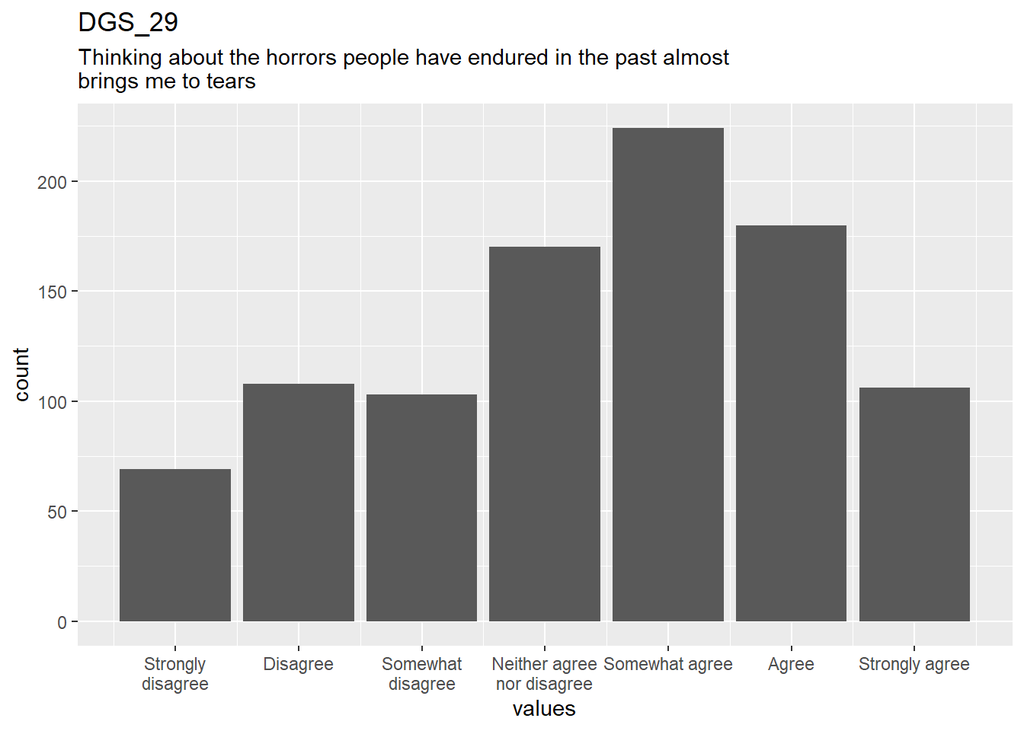

Distribution of values for DGS_29

0 missing values.

#### Summary statistics

| name | label | data_type | n_missing | complete_rate | min | median | max | mean | sd | n_value_labels | hist |
| --- | --- | --- | --- | --- | --- | --- | --- | --- | --- | --- | --- |
| DGS_29 | Thinking about the horrors people have endured in the past almost brings me to tears | haven_labelled | 0 | 1 | 1 | 5 | 7 | 4.391667 | 1.740978 | 7 | ▂▃▃▆▁▇▆▃ |

#### Value labels

Response choices

| name | value |
| --- | --- |
| Strongly disagree | 1 |
| Disagree | 2 |
| Somewhat disagree | 3 |
| Neither agree nor disagree | 4 |
| Somewhat agree | 5 |
| Agree | 6 |
| Strongly agree | 7 |

### DGS_46

I feel great concern for the people who have to suffer in the world right now

#### Distribution

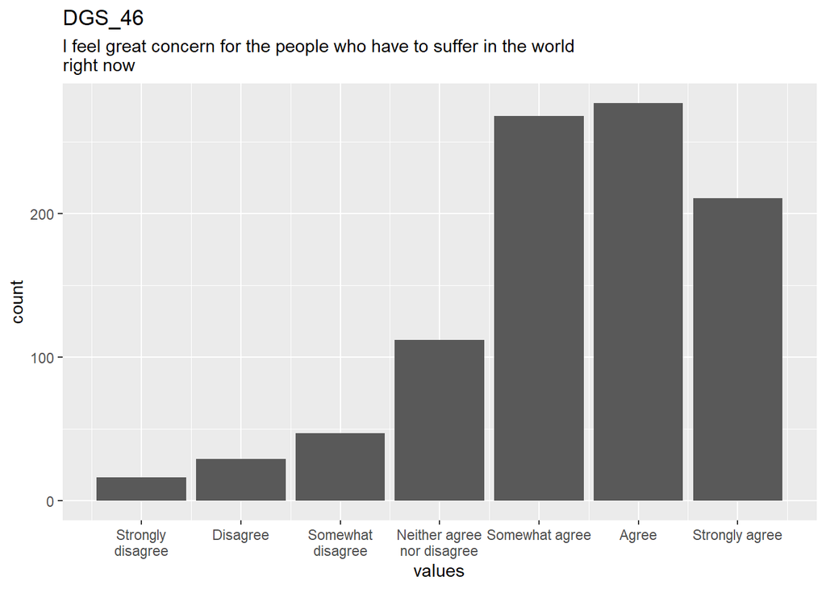

Distribution of values for DGS_46

0 missing values.

#### Summary statistics

| name | label | data_type | n_missing | complete_rate | min | median | max | mean | sd | n_value_labels | hist |
| --- | --- | --- | --- | --- | --- | --- | --- | --- | --- | --- | --- |
| DGS_46 | I feel great concern for the people who have to suffer in the world right now | haven_labelled | 0 | 1 | 1 | 6 | 7 | 5.35625 | 1.376157 | 7 | ▁▁▂▃▁▇▇▆ |

#### Value labels

Response choices

| name | value |
| --- | --- |
| Strongly disagree | 1 |
| Disagree | 2 |
| Somewhat disagree | 3 |
| Neither agree nor disagree | 4 |
| Somewhat agree | 5 |
| Agree | 6 |
| Strongly agree | 7 |

### DGS_52

Thinking about the suffering of others, even of those who I don’t know, will put me in deep sorrow

#### Distribution

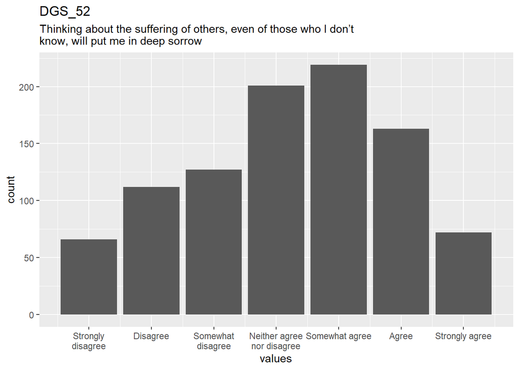

Distribution of values for DGS_52

0 missing values.

#### Summary statistics

| name | label | data_type | n_missing | complete_rate | min | median | max | mean | sd | n_value_labels | hist |
| --- | --- | --- | --- | --- | --- | --- | --- | --- | --- | --- | --- |
| DGS_52 | Thinking about the suffering of others, even of those who I don’t know, will put me in deep sorrow | haven_labelled | 0 | 1 | 1 | 4 | 7 | 4.220833 | 1.659549 | 7 | ▂▅▅▇▁▇▆▂ |

#### Value labels

Response choices

| name | value |
| --- | --- |
| Strongly disagree | 1 |
| Disagree | 2 |
| Somewhat disagree | 3 |
| Neither agree nor disagree | 4 |
| Somewhat agree | 5 |
| Agree | 6 |
| Strongly agree | 7 |

### DGS_28

I feel guilty when I spend too much time on myself because it can be better used for moral causes

#### Distribution

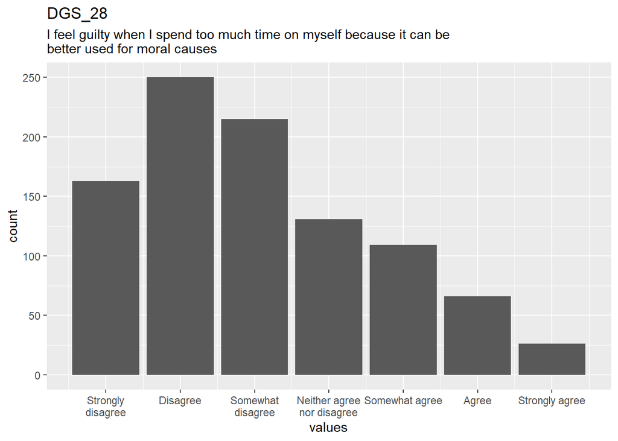

Distribution of values for DGS_28

0 missing values.

#### Summary statistics

| name | label | data_type | n_missing | complete_rate | min | median | max | mean | sd | n_value_labels | hist |
| --- | --- | --- | --- | --- | --- | --- | --- | --- | --- | --- | --- |
| DGS_28 | I feel guilty when I spend too much time on myself because it can be better used for moral causes | haven_labelled | 0 | 1 | 1 | 3 | 7 | 3.078125 | 1.605887 | 7 | ▅▇▇▅▁▃▂▁ |

#### Value labels

Response choices

| name | value |
| --- | --- |
| Strongly disagree | 1 |
| Disagree | 2 |
| Somewhat disagree | 3 |
| Neither agree nor disagree | 4 |
| Somewhat agree | 5 |
| Agree | 6 |
| Strongly agree | 7 |

### DGS_35

I feel bad when I waste my time because it could be used to help others

#### Distribution

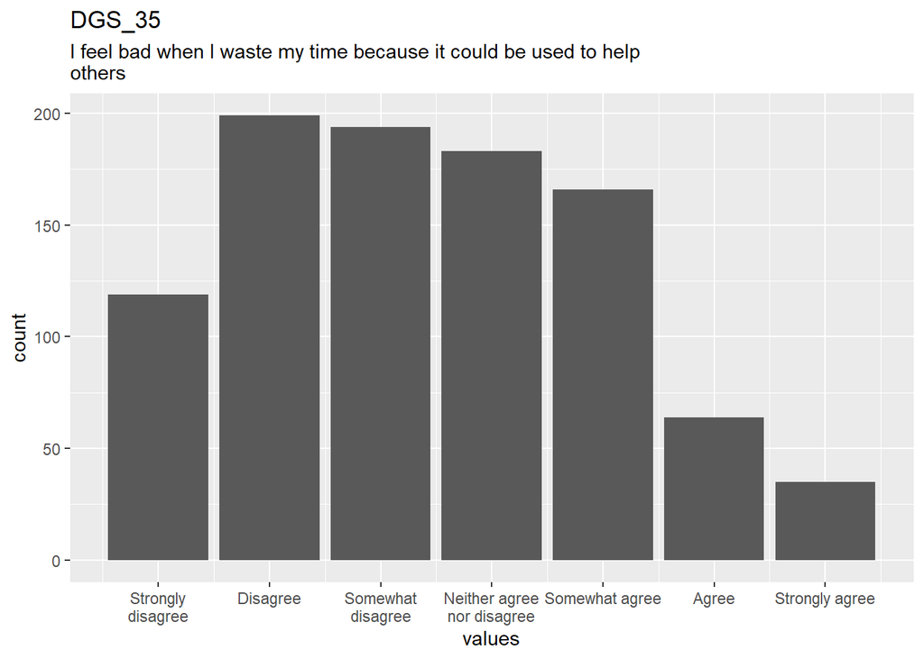

Distribution of values for DGS_35

0 missing values.

#### Summary statistics

| name | label | data_type | n_missing | complete_rate | min | median | max | mean | sd | n_value_labels | hist |
| --- | --- | --- | --- | --- | --- | --- | --- | --- | --- | --- | --- |
| DGS_35 | I feel bad when I waste my time because it could be used to help others | haven_labelled | 0 | 1 | 1 | 3 | 7 | 3.427083 | 1.609052 | 7 | ▅▇▇▇▁▇▂▂ |

#### Value labels

Response choices

| name | value |
| --- | --- |
| Strongly disagree | 1 |
| Disagree | 2 |
| Somewhat disagree | 3 |
| Neither agree nor disagree | 4 |
| Somewhat agree | 5 |
| Agree | 6 |
| Strongly agree | 7 |

### DGS_48

I spend little time on myself so that I can have more time to help others

#### Distribution

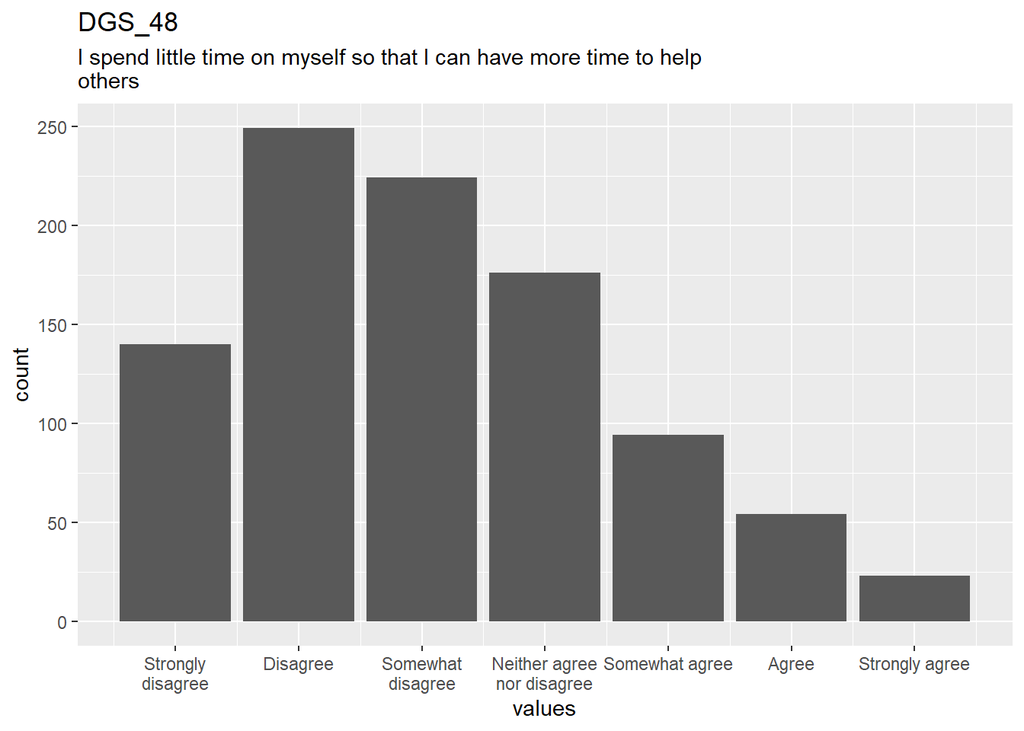

Distribution of values for DGS_48

0 missing values.

#### Summary statistics

| name | label | data_type | n_missing | complete_rate | min | median | max | mean | sd | n_value_labels | hist |
| --- | --- | --- | --- | --- | --- | --- | --- | --- | --- | --- | --- |
| DGS_48 | I spend little time on myself so that I can have more time to help others | haven_labelled | 0 | 1 | 1 | 3 | 7 | 3.092708 | 1.516936 | 7 | ▅▇▇▆▁▃▂▁ |

#### Value labels

Response choices

| name | value |
| --- | --- |
| Strongly disagree | 1 |
| Disagree | 2 |
| Somewhat disagree | 3 |
| Neither agree nor disagree | 4 |
| Somewhat agree | 5 |
| Agree | 6 |
| Strongly agree | 7 |

### DGS_68

Whenever I spend unnecessary money on myself, I feel bad for not contributing them to those in need

#### Distribution

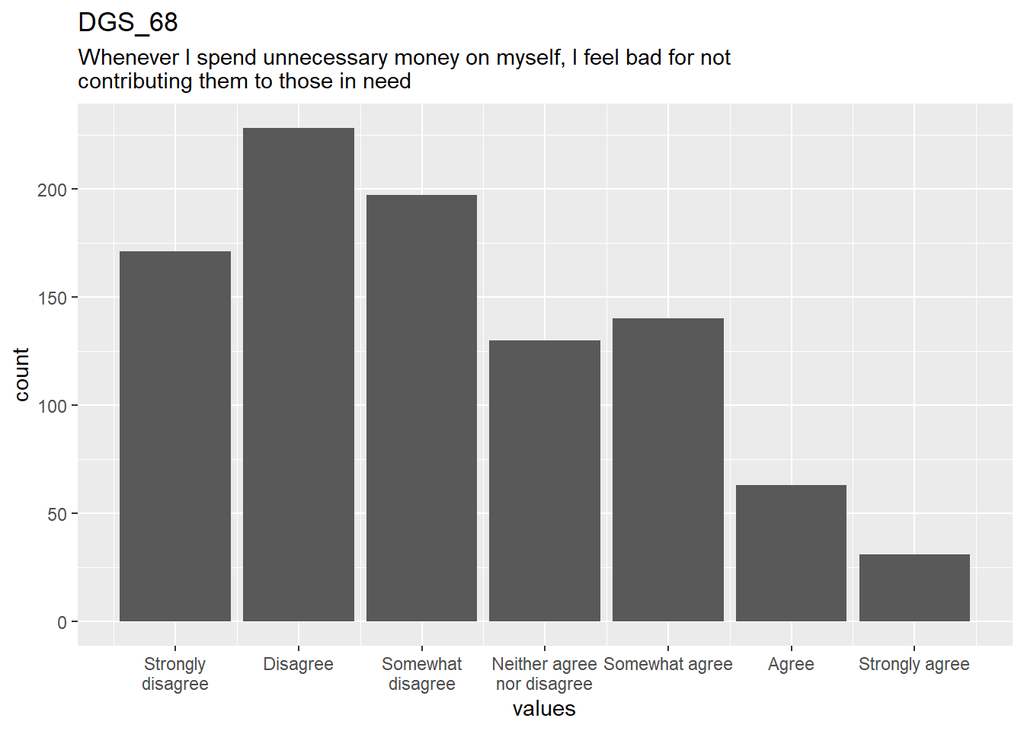

Distribution of values for DGS_68

0 missing values.

#### Summary statistics

| name | label | data_type | n_missing | complete_rate | min | median | max | mean | sd | n_value_labels | hist |
| --- | --- | --- | --- | --- | --- | --- | --- | --- | --- | --- | --- |
| DGS_68 | Whenever I spend unnecessary money on myself, I feel bad for not contributing them to those in need | haven_labelled | 0 | 1 | 1 | 3 | 7 | 3.159375 | 1.65937 | 7 | ▆▇▇▅▁▅▂▁ |

#### Value labels

Response choices

| name | value |
| --- | --- |
| Strongly disagree | 1 |
| Disagree | 2 |
| Somewhat disagree | 3 |
| Neither agree nor disagree | 4 |
| Somewhat agree | 5 |
| Agree | 6 |
| Strongly agree | 7 |

### DGS_21

There is too much need in the world for me to be able to do anything about it

#### Distribution

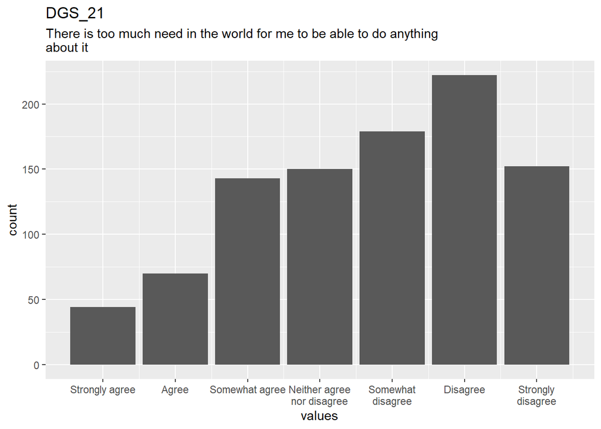

Distribution of values for DGS_21

0 missing values.

#### Summary statistics

| name | label | data_type | n_missing | complete_rate | min | median | max | mean | sd | n_value_labels | hist |
| --- | --- | --- | --- | --- | --- | --- | --- | --- | --- | --- | --- |
| DGS_21 | There is too much need in the world for me to be able to do anything about it | haven_labelled | 0 | 1 | 1 | 5 | 7 | 4.691667 | 1.707108 | 7 | ▂▂▅▆▁▆▇▆ |

#### Value labels

Response choices

| name | value |
| --- | --- |
| Strongly disagree | 7 |
| Disagree | 6 |
| Somewhat disagree | 5 |
| Neither agree nor disagree | 4 |
| Somewhat agree | 3 |
| Agree | 2 |
| Strongly agree | 1 |

### DGS_44

The problems of the world are so large there is no point in trying to do anything about them

#### Distribution

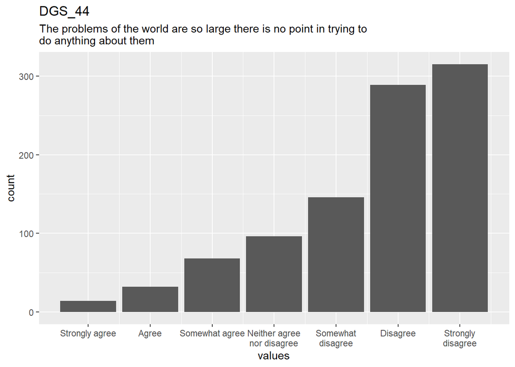

Distribution of values for DGS_44

0 missing values.

#### Summary statistics

| name | label | data_type | n_missing | complete_rate | min | median | max | mean | sd | n_value_labels | hist |
| --- | --- | --- | --- | --- | --- | --- | --- | --- | --- | --- | --- |
| DGS_44 | The problems of the world are so large there is no point in trying to do anything about them | haven_labelled | 0 | 1 | 1 | 6 | 7 | 5.557292 | 1.49062 | 7 | ▁▁▂▂▁▃▇▇ |

#### Value labels

Response choices

| name | value |
| --- | --- |
| Strongly disagree | 7 |
| Disagree | 6 |
| Somewhat disagree | 5 |
| Neither agree nor disagree | 4 |
| Somewhat agree | 3 |
| Agree | 2 |
| Strongly agree | 1 |

### DGS_65

The needs of the world seem too large for me to have any impact on them

#### Distribution

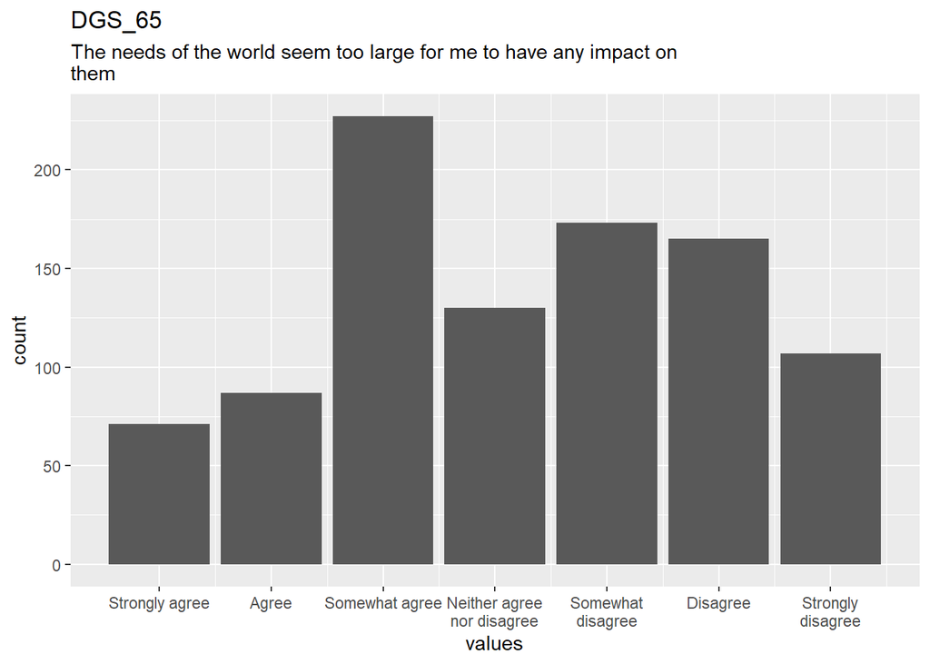

Distribution of values for DGS_65

0 missing values.

#### Summary statistics

| name | label | data_type | n_missing | complete_rate | min | median | max | mean | sd | n_value_labels | hist |
| --- | --- | --- | --- | --- | --- | --- | --- | --- | --- | --- | --- |
| DGS_65 | The needs of the world seem too large for me to have any impact on them | haven_labelled | 0 | 1 | 1 | 4 | 7 | 4.21875 | 1.758063 | 7 | ▂▃▇▅▁▆▆▃ |

#### Value labels

Response choices

| name | value |
| --- | --- |
| Strongly disagree | 7 |
| Disagree | 6 |
| Somewhat disagree | 5 |
| Neither agree nor disagree | 4 |
| Somewhat agree | 3 |
| Agree | 2 |
| Strongly agree | 1 |

### DGS_6

I care about strangers almost as much as I care about my family

#### Distribution

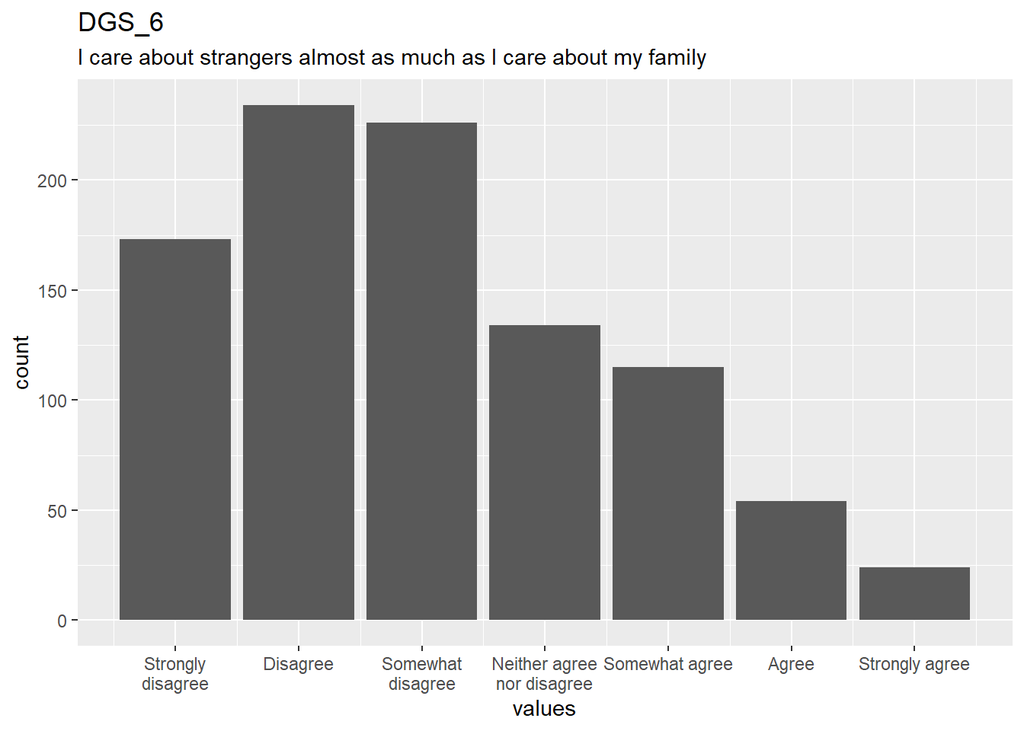

Distribution of values for DGS_6

0 missing values.

#### Summary statistics

| name | label | data_type | n_missing | complete_rate | min | median | max | mean | sd | n_value_labels | hist |
| --- | --- | --- | --- | --- | --- | --- | --- | --- | --- | --- | --- |
| DGS_6 | I care about strangers almost as much as I care about my family | haven_labelled | 0 | 1 | 1 | 3 | 7 | 3.04375 | 1.578057 | 7 | ▆▇▇▅▁▃▂▁ |

#### Value labels

Response choices

| name | value |
| --- | --- |
| Strongly disagree | 1 |
| Disagree | 2 |
| Somewhat disagree | 3 |
| Neither agree nor disagree | 4 |
| Somewhat agree | 5 |
| Agree | 6 |
| Strongly agree | 7 |

### DGS_38

I would always save people I love before I would save people I don’t know

#### Distribution

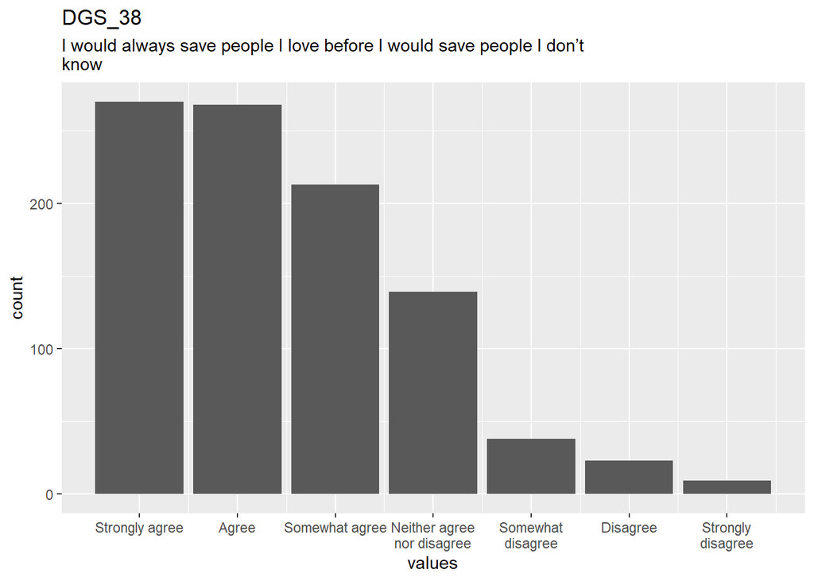

Distribution of values for DGS_38

0 missing values.

#### Summary statistics

| name | label | data_type | n_missing | complete_rate | min | median | max | mean | sd | n_value_labels | hist |
| --- | --- | --- | --- | --- | --- | --- | --- | --- | --- | --- | --- |
| DGS_38 | I would always save people I love before I would save people I don’t know | haven_labelled | 0 | 1 | 1 | 2 | 7 | 2.491667 | 1.347741 | 7 | ▇▇▆▅▁▁▁▁ |

#### Value labels

Response choices

| name | value |
| --- | --- |
| Strongly disagree | 7 |
| Disagree | 6 |
| Somewhat disagree | 5 |
| Neither agree nor disagree | 4 |
| Somewhat agree | 3 |
| Agree | 2 |
| Strongly agree | 1 |

### DGS_39

I care about everyone in the world as I would care for my own child

#### Distribution

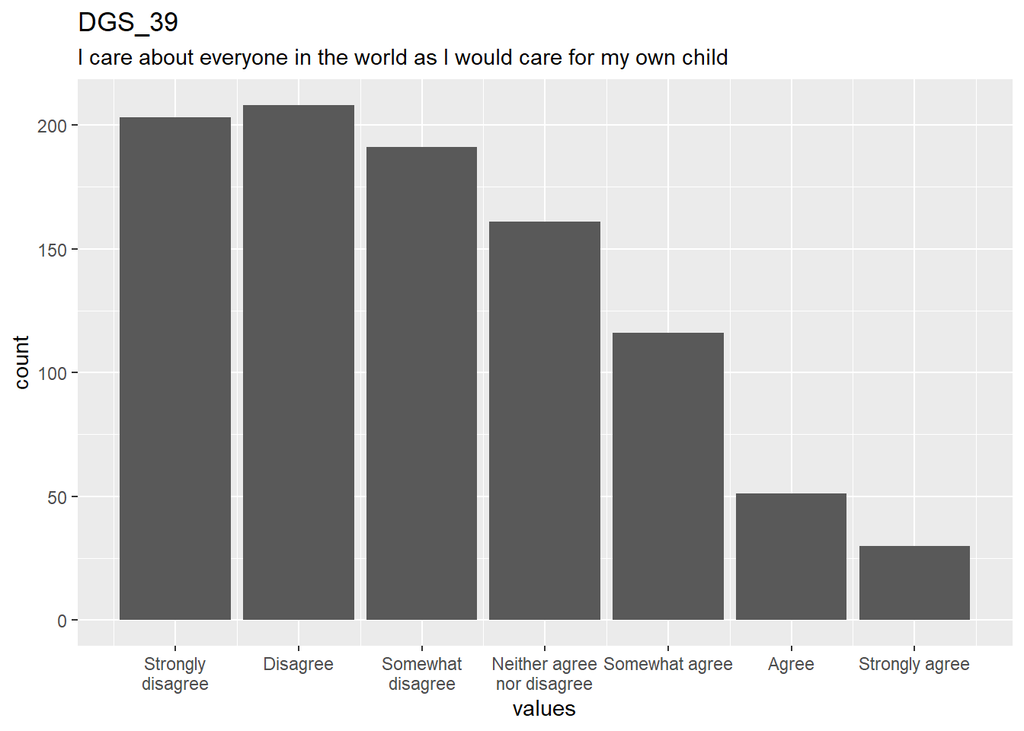

Distribution of values for DGS_39

0 missing values.

#### Summary statistics

| name | label | data_type | n_missing | complete_rate | min | median | max | mean | sd | n_value_labels | hist |
| --- | --- | --- | --- | --- | --- | --- | --- | --- | --- | --- | --- |
| DGS_39 | I care about everyone in the world as I would care for my own child | haven_labelled | 0 | 1 | 1 | 3 | 7 | 3.054167 | 1.64059 | 7 | ▇▇▇▆▁▅▂▁ |

#### Value labels

Response choices

| name | value |
| --- | --- |
| Strongly disagree | 1 |
| Disagree | 2 |
| Somewhat disagree | 3 |
| Neither agree nor disagree | 4 |
| Somewhat agree | 5 |
| Agree | 6 |
| Strongly agree | 7 |

### DGS_70

I value the importance of some people more than others

#### Distribution

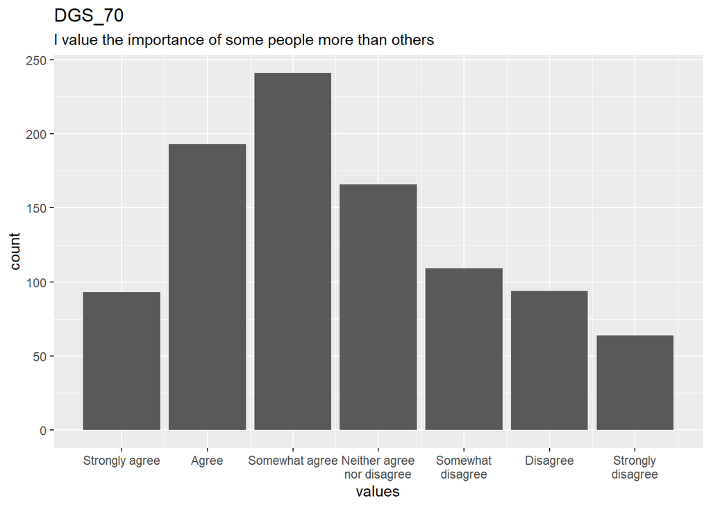

Distribution of values for DGS_70

0 missing values.

#### Summary statistics

| name | label | data_type | n_missing | complete_rate | min | median | max | mean | sd | n_value_labels | hist |
| --- | --- | --- | --- | --- | --- | --- | --- | --- | --- | --- | --- |
| DGS_70 | I value the importance of some people more than others | haven_labelled | 0 | 1 | 1 | 3 | 7 | 3.565625 | 1.68718 | 7 | ▃▆▇▆▁▃▃▂ |

#### Value labels

Response choices

| name | value |
| --- | --- |
| Strongly disagree | 7 |
| Disagree | 6 |
| Somewhat disagree | 5 |
| Neither agree nor disagree | 4 |
| Somewhat agree | 3 |
| Agree | 2 |
| Strongly agree | 1 |

### DGS_71

If I only have a chance, I am more willing to save the people that are close to me compared to strangers

#### Distribution

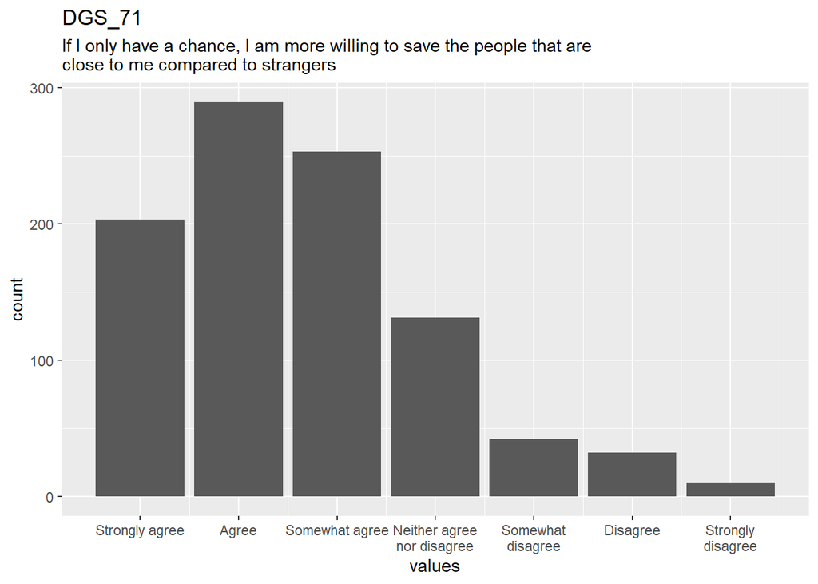

Distribution of values for DGS_71

0 missing values.

#### Summary statistics

| name | label | data_type | n_missing | complete_rate | min | median | max | mean | sd | n_value_labels | hist |
| --- | --- | --- | --- | --- | --- | --- | --- | --- | --- | --- | --- |
| DGS_71 | If I only have a chance, I am more willing to save the people that are close to me compared to strangers | haven_labelled | 0 | 1 | 1 | 2 | 7 | 2.641667 | 1.341071 | 7 | ▆▇▇▃▁▁▁▁ |

#### Value labels

Response choices

| name | value |
| --- | --- |
| Strongly disagree | 7 |
| Disagree | 6 |
| Somewhat disagree | 5 |
| Neither agree nor disagree | 4 |
| Somewhat agree | 3 |
| Agree | 2 |
| Strongly agree | 1 |

### DGS_56

I will seek out opportunities when I can help others, not just when people express needs

#### Distribution

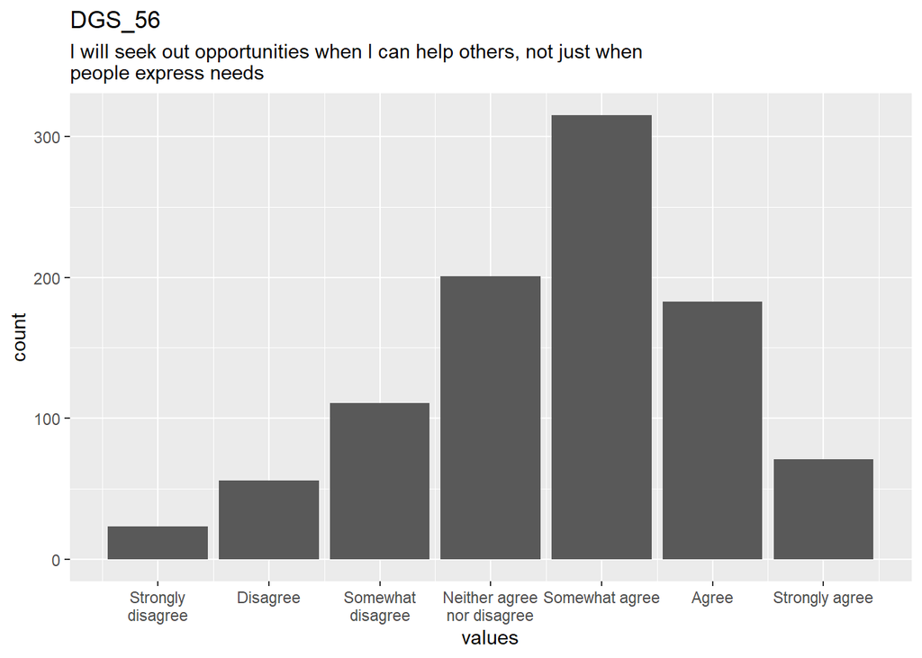

Distribution of values for DGS_56

0 missing values.

#### Summary statistics

| name | label | data_type | n_missing | complete_rate | min | median | max | mean | sd | n_value_labels | hist |
| --- | --- | --- | --- | --- | --- | --- | --- | --- | --- | --- | --- |
| DGS_56 | I will seek out opportunities when I can help others, not just when people express needs | haven_labelled | 0 | 1 | 1 | 5 | 7 | 4.627083 | 1.389104 | 7 | ▁▂▃▅▁▇▅▂ |

#### Value labels

Response choices

| name | value |
| --- | --- |
| Strongly disagree | 1 |
| Disagree | 2 |
| Somewhat disagree | 3 |
| Neither agree nor disagree | 4 |
| Somewhat agree | 5 |
| Agree | 6 |
| Strongly agree | 7 |

### HEXACO_C_1

I plan ahead and organize things, to avoid scrambling at the last minute

#### Distribution

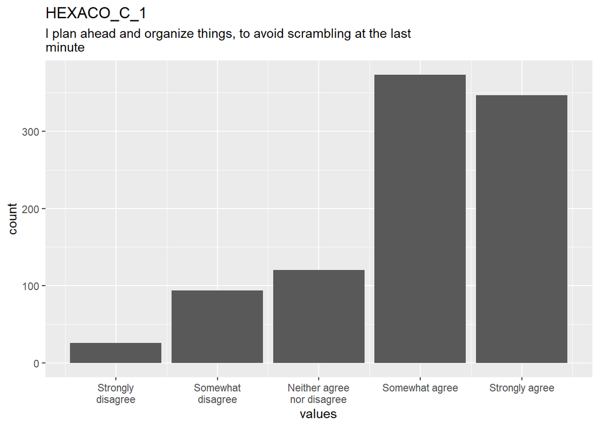

Distribution of values for HEXACO_C_1

0 missing values.

#### Summary statistics

| name | label | data_type | n_missing | complete_rate | min | median | max | mean | sd | n_value_labels | hist |
| --- | --- | --- | --- | --- | --- | --- | --- | --- | --- | --- | --- |
| HEXACO_C_1 | I plan ahead and organize things, to avoid scrambling at the last minute | haven_labelled | 0 | 1 | 1 | 4 | 5 | 3.959375 | 1.058958 | 5 | ▁▂▁▂▁▇▁▇ |

#### Value labels

Response choices

| name | value |
| --- | --- |
| Strongly disagree | 1 |
| Somewhat disagree | 2 |
| Neither agree nor disagree | 3 |
| Somewhat agree | 4 |
| Strongly agree | 5 |

### HEXACO_C_2

When working, I sometimes have difficulties due to being disorganized

#### Distribution

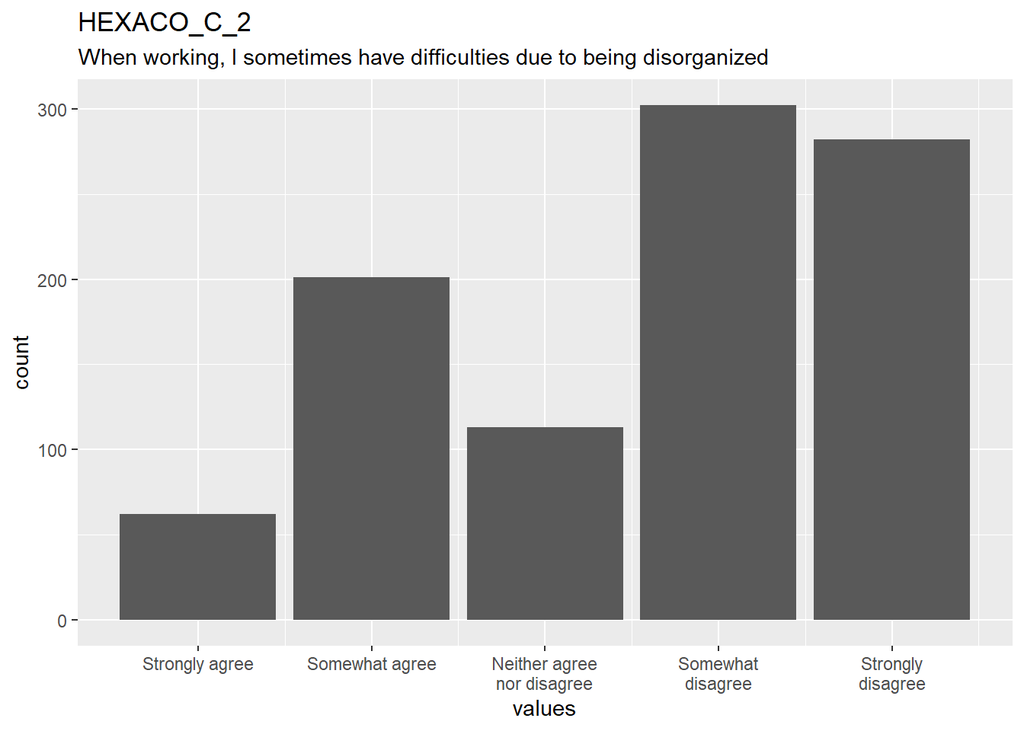

Distribution of values for HEXACO_C_2

0 missing values.

#### Summary statistics

| name | label | data_type | n_missing | complete_rate | min | median | max | mean | sd | n_value_labels | hist |
| --- | --- | --- | --- | --- | --- | --- | --- | --- | --- | --- | --- |
| HEXACO_C_2 | When working, I sometimes have difficulties due to being disorganized | haven_labelled | 0 | 1 | 1 | 4 | 5 | 3.563542 | 1.28118 | 5 | ▂▅▁▃▁▇▁▇ |

#### Value labels

Response choices

| name | value |
| --- | --- |
| Strongly disagree | 5 |
| Somewhat disagree | 4 |
| Neither agree nor disagree | 3 |
| Somewhat agree | 2 |
| Strongly agree | 1 |

### HEXACO_C_3

I often push myself very hard when trying to achieve a goal

#### Distribution

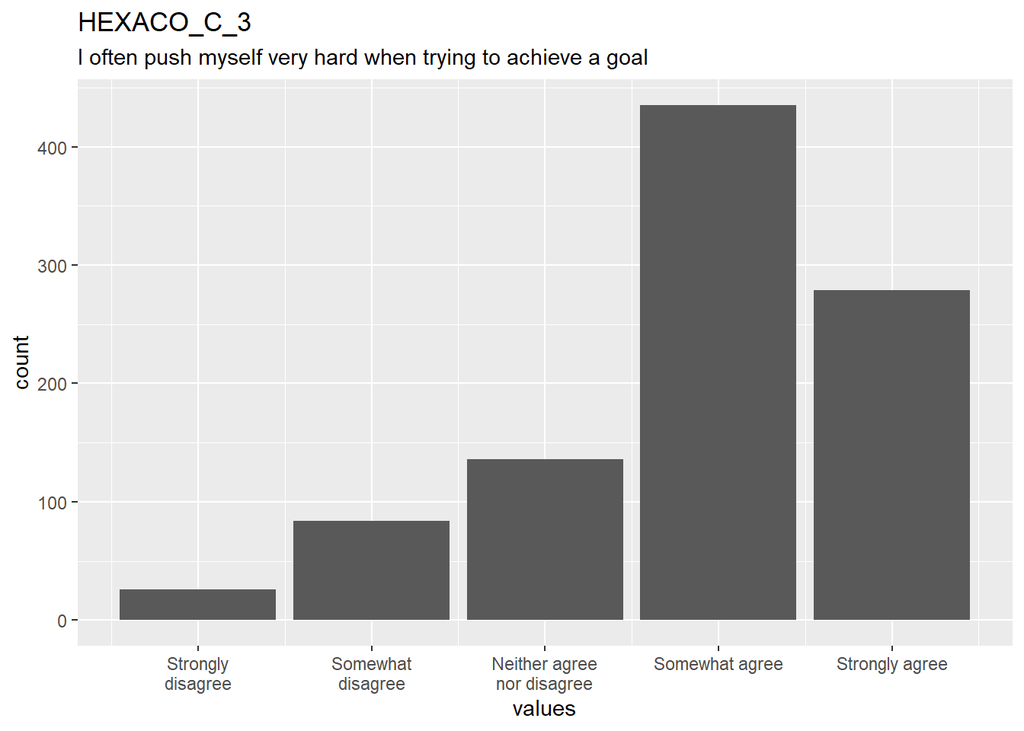

Distribution of values for HEXACO_C_3

0 missing values.

#### Summary statistics

| name | label | data_type | n_missing | complete_rate | min | median | max | mean | sd | n_value_labels | hist |
| --- | --- | --- | --- | --- | --- | --- | --- | --- | --- | --- | --- |
| HEXACO_C_3 | I often push myself very hard when trying to achieve a goal | haven_labelled | 0 | 1 | 1 | 4 | 5 | 3.892708 | 1.007764 | 5 | ▁▂▁▂▁▇▁▅ |

#### Value labels

Response choices

| name | value |
| --- | --- |
| Strongly disagree | 1 |
| Somewhat disagree | 2 |
| Neither agree nor disagree | 3 |
| Somewhat agree | 4 |
| Strongly agree | 5 |

### HEXACO_C_4

When working on something, I don’t pay much attention to small details

#### Distribution

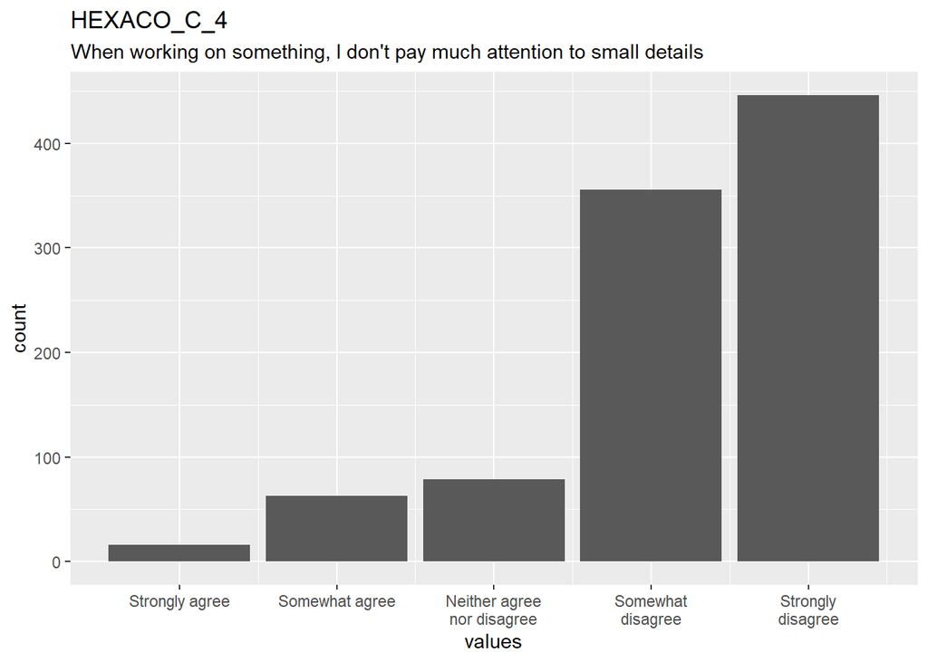

Distribution of values for HEXACO_C_4

0 missing values.

#### Summary statistics

| name | label | data_type | n_missing | complete_rate | min | median | max | mean | sd | n_value_labels | hist |
| --- | --- | --- | --- | --- | --- | --- | --- | --- | --- | --- | --- |
| HEXACO_C_4 | When working on something, I don’t pay much attention to small details | haven_labelled | 0 | 1 | 1 | 4 | 5 | 4.201042 | 0.9591223 | 5 | ▁▁▁▂▁▆▁▇ |

#### Value labels

Response choices

| name | value |
| --- | --- |
| Strongly disagree | 5 |
| Somewhat disagree | 4 |
| Neither agree nor disagree | 3 |
| Somewhat agree | 2 |
| Strongly agree | 1 |

### HEXACO_C_5

I do only the minimum amount of work needed to get by

#### Distribution

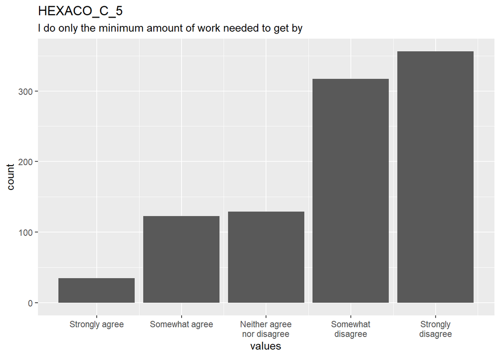

Distribution of values for HEXACO_C_5

0 missing values.

#### Summary statistics

| name | label | data_type | n_missing | complete_rate | min | median | max | mean | sd | n_value_labels | hist |
| --- | --- | --- | --- | --- | --- | --- | --- | --- | --- | --- | --- |
| HEXACO_C_5 | I do only the minimum amount of work needed to get by | haven_labelled | 0 | 1 | 1 | 4 | 5 | 3.870833 | 1.153488 | 5 | ▁▃▁▃▁▇▁▇ |

#### Value labels

Response choices

| name | value |
| --- | --- |
| Strongly disagree | 5 |
| Somewhat disagree | 4 |
| Neither agree nor disagree | 3 |
| Somewhat agree | 2 |
| Strongly agree | 1 |

### HEXACO_C_6

I always try to be accurate in my work, even at the expense of time

#### Distribution

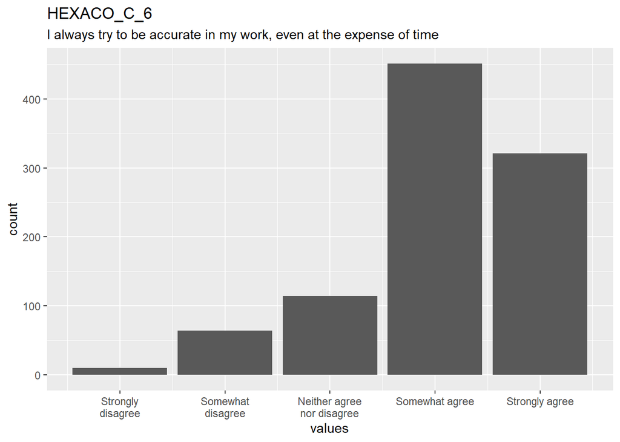

Distribution of values for HEXACO_C_6

0 missing values.

#### Summary statistics

| name | label | data_type | n_missing | complete_rate | min | median | max | mean | sd | n_value_labels | hist |
| --- | --- | --- | --- | --- | --- | --- | --- | --- | --- | --- | --- |
| HEXACO_C_6 | I always try to be accurate in my work, even at the expense of time | haven_labelled | 0 | 1 | 1 | 4 | 5 | 4.051042 | 0.9009895 | 5 | ▁▁▁▂▁▇▁▆ |

#### Value labels

Response choices

| name | value |
| --- | --- |
| Strongly disagree | 1 |
| Somewhat disagree | 2 |
| Neither agree nor disagree | 3 |
| Somewhat agree | 4 |
| Strongly agree | 5 |

### HEXACO_C_7

I make decisions based on the feeling of the moment rather than on careful thought

#### Distribution

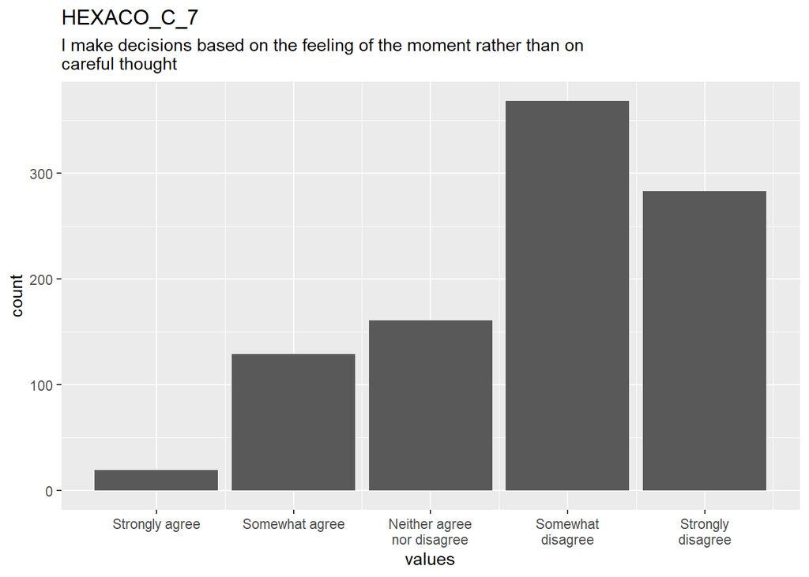

Distribution of values for HEXACO_C_7

0 missing values.

#### Summary statistics

| name | label | data_type | n_missing | complete_rate | min | median | max | mean | sd | n_value_labels | hist |
| --- | --- | --- | --- | --- | --- | --- | --- | --- | --- | --- | --- |
| HEXACO_C_7 | I make decisions based on the feeling of the moment rather than on careful thought | haven_labelled | 0 | 1 | 1 | 4 | 5 | 3.798958 | 1.06719 | 5 | ▁▃▁▃▁▇▁▆ |

#### Value labels

Response choices

| name | value |
| --- | --- |
| Strongly disagree | 5 |
| Somewhat disagree | 4 |
| Neither agree nor disagree | 3 |
| Somewhat agree | 2 |
| Strongly agree | 1 |

### HEXACO_C_8

I make a lot of mistakes because I don’t think before I act

#### Distribution

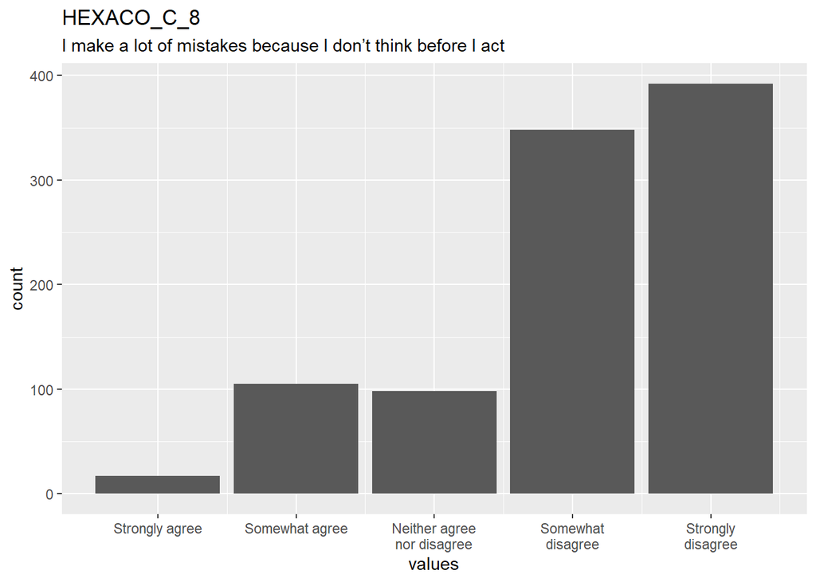

Distribution of values for HEXACO_C_8

0 missing values.

#### Summary statistics

| name | label | data_type | n_missing | complete_rate | min | median | max | mean | sd | n_value_labels | hist |
| --- | --- | --- | --- | --- | --- | --- | --- | --- | --- | --- | --- |
| HEXACO_C_8 | I make a lot of mistakes because I don’t think before I act | haven_labelled | 0 | 1 | 1 | 4 | 5 | 4.034375 | 1.052266 | 5 | ▁▂▁▂▁▇▁▇ |

#### Value labels

Response choices

| name | value |
| --- | --- |
| Strongly disagree | 5 |
| Somewhat disagree | 4 |
| Neither agree nor disagree | 3 |
| Somewhat agree | 2 |
| Strongly agree | 1 |

### HEXACO_C_9

People often call me a perfectionist

#### Distribution

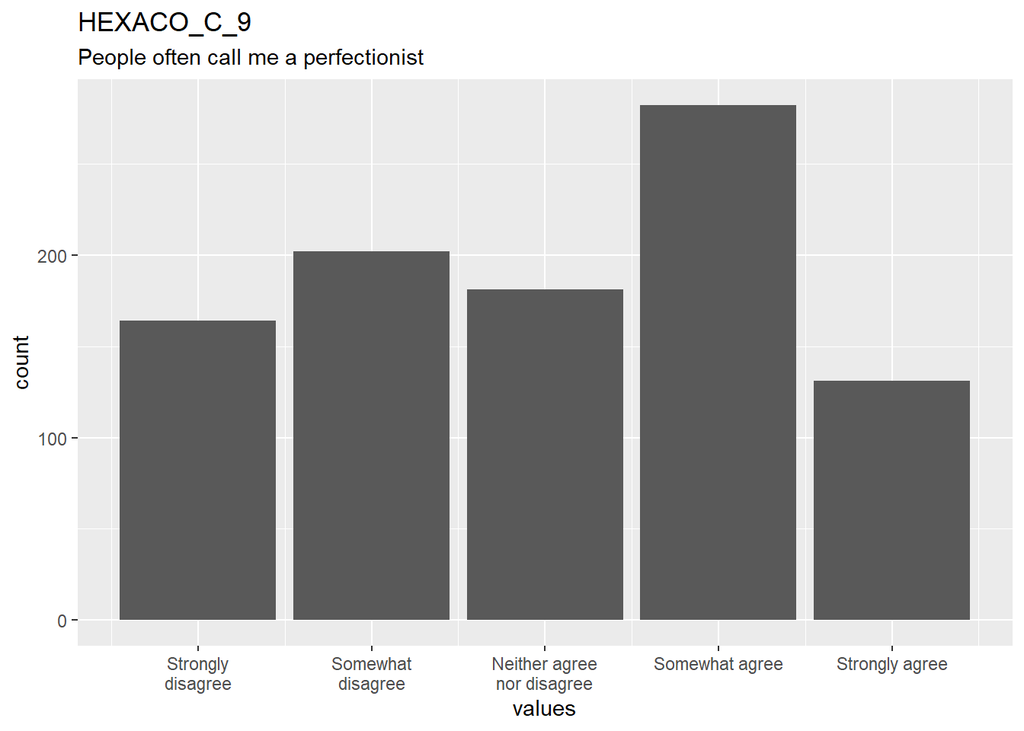

Distribution of values for HEXACO_C_9

0 missing values.

#### Summary statistics

| name | label | data_type | n_missing | complete_rate | min | median | max | mean | sd | n_value_labels | hist |
| --- | --- | --- | --- | --- | --- | --- | --- | --- | --- | --- | --- |
| HEXACO_C_9 | People often call me a perfectionist | haven_labelled | 0 | 1 | 1 | 3 | 5 | 3.014583 | 1.317167 | 5 | ▅▆▁▅▁▇▁▃ |

#### Value labels

Response choices

| name | value |
| --- | --- |
| Strongly disagree | 1 |
| Somewhat disagree | 2 |
| Neither agree nor disagree | 3 |
| Somewhat agree | 4 |
| Strongly agree | 5 |

### HEXACO_C_10

I prefer to do whatever comes to mind, rather than stick to a plan.

#### Distribution

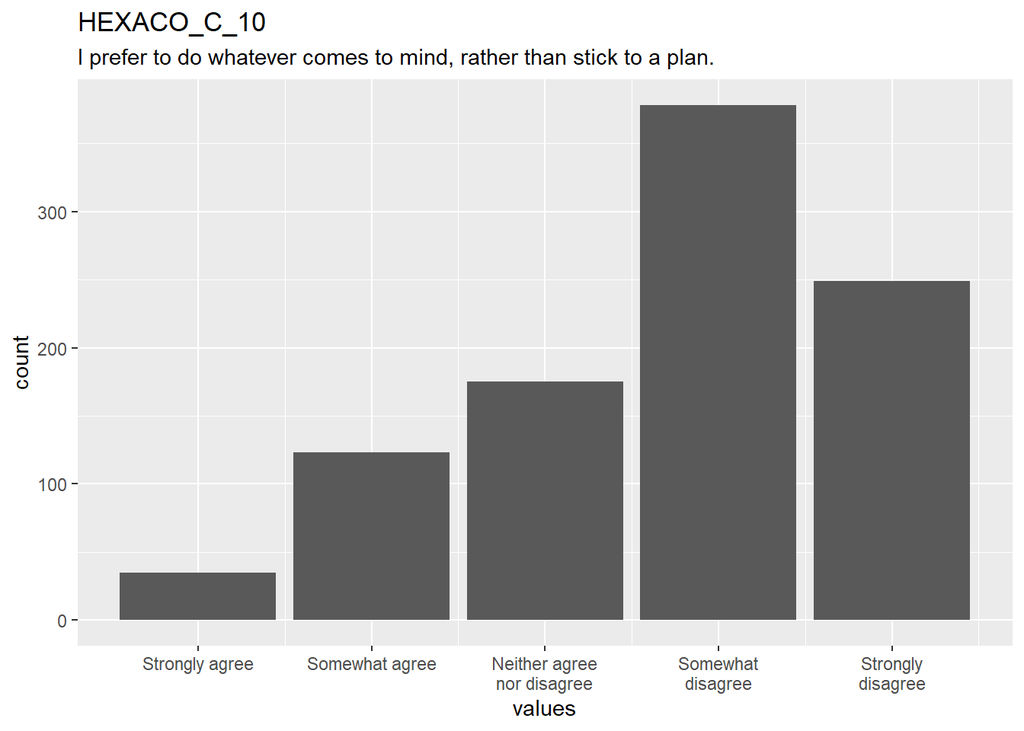

Distribution of values for HEXACO_C_10

0 missing values.

#### Summary statistics

| name | label | data_type | n_missing | complete_rate | min | median | max | mean | sd | n_value_labels | hist |
| --- | --- | --- | --- | --- | --- | --- | --- | --- | --- | --- | --- |
| HEXACO_C_10 | I prefer to do whatever comes to mind, rather than stick to a plan. | haven_labelled | 0 | 1 | 1 | 4 | 5 | 3.711458 | 1.095576 | 5 | ▁▂▁▃▁▇▁▅ |

#### Value labels

Response choices

| name | value |
| --- | --- |
| Strongly disagree | 5 |
| Somewhat disagree | 4 |
| Neither agree nor disagree | 3 |
| Somewhat agree | 2 |
| Strongly agree | 1 |

### Age

Please indicate your age in years.

#### Distribution

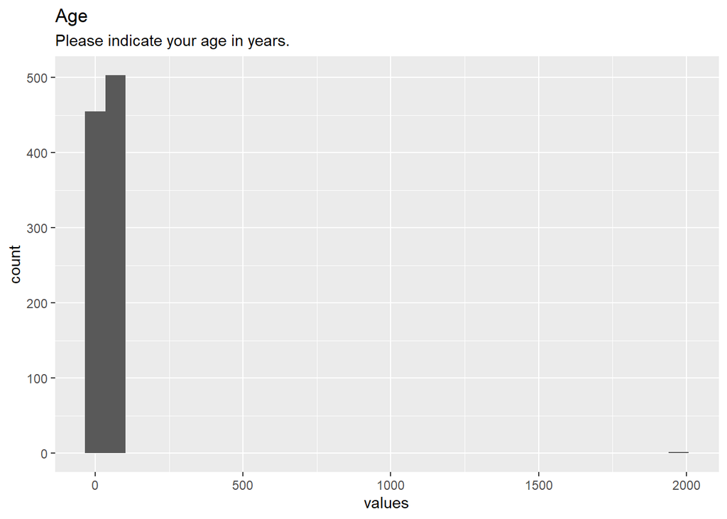

Distribution of values for Age

0 missing values.

#### Summary statistics

| name | label | data_type | n_missing | complete_rate | min | median | max | mean | sd | hist |
| --- | --- | --- | --- | --- | --- | --- | --- | --- | --- | --- |
| Age | Please indicate your age in years. | numeric | 0 | 1 | 18 | 35 | 1992 | 42.10938 | 89.84052 | ▇▁▁▁▁ |

### Gender

What gender do you identify as?

#### Distribution

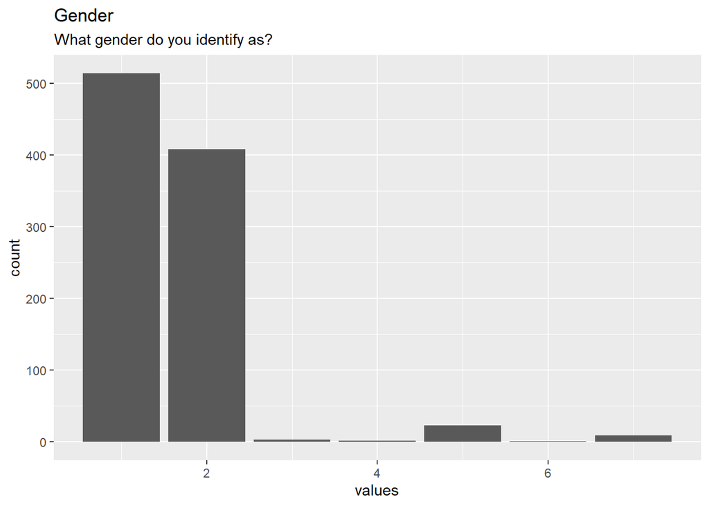

Distribution of values for Gender

0 missing values.

#### Summary statistics

| name | label | data_type | n_missing | complete_rate | min | median | max | mean | sd | hist |
| --- | --- | --- | --- | --- | --- | --- | --- | --- | --- | --- |
| Gender | What gender do you identify as? | numeric | 0 | 1 | 1 | 1 | 7 | 1.594792 | 0.9220811 | ▇▁▁▁▁ |

### Race

Please indicate your race (select all that apply)

#### Distribution

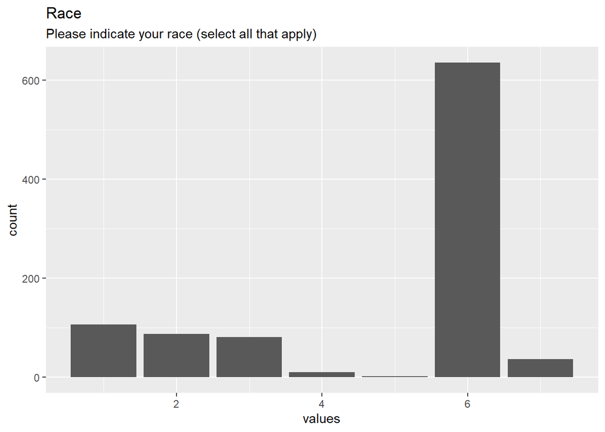

Distribution of values for Race

0 missing values.

#### Summary statistics

| name | label | data_type | n_missing | complete_rate | min | median | max | mean | sd | hist |
| --- | --- | --- | --- | --- | --- | --- | --- | --- | --- | --- |
| Race | Please indicate your race (select all that apply) | numeric | 0 | 1 | 1 | 6 | 7 | 4.838542 | 1.936417 | ▂▁▁▁▇ |

### Degree

Please indicate the highest degree or level of education that you have completed.

#### Distribution

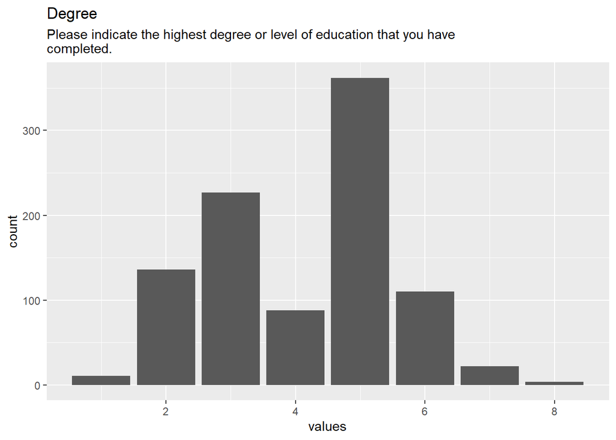

Distribution of values for Degree

0 missing values.

#### Summary statistics

| name | label | data_type | n_missing | complete_rate | min | median | max | mean | sd | hist |
| --- | --- | --- | --- | --- | --- | --- | --- | --- | --- | --- |
| Degree | Please indicate the highest degree or level of education that you have completed. | numeric | 0 | 1 | 1 | 5 | 8 | 4.1375 | 1.413421 | ▂▅▇▂▁ |

### Income

What is your household income?

#### Distribution

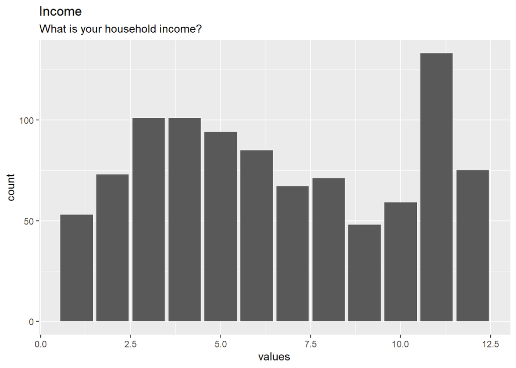

Distribution of values for Income

0 missing values.

#### Summary statistics

| name | label | data_type | n_missing | complete_rate | min | median | max | mean | sd | hist |
| --- | --- | --- | --- | --- | --- | --- | --- | --- | --- | --- |
| Income | What is your household income? | numeric | 0 | 1 | 1 | 6 | 12 | 6.570833 | 3.438599 | ▇▆▅▃▇ |

### Religion

What is your present religion, if any?

#### Distribution

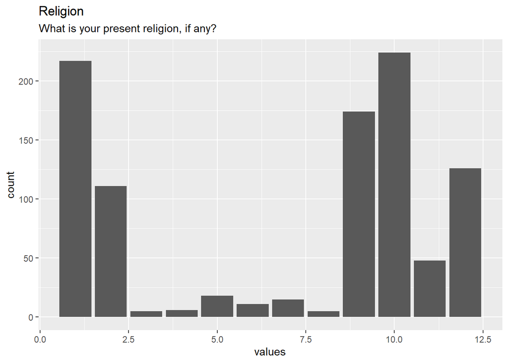

Distribution of values for Religion

0 missing values.

#### Summary statistics

| name | label | data_type | n_missing | complete_rate | min | median | max | mean | sd | hist |
| --- | --- | --- | --- | --- | --- | --- | --- | --- | --- | --- |
| Religion | What is your present religion, if any? | numeric | 0 | 1 | 1 | 9 | 12 | 6.901042 | 4.263187 | ▇▁▁▃▇ |